# Librerías

# Visualización de los datos

```python
Y = XY[['A-B', 'C-D', 'E', 'F-G']]
X = XY[XY.columns.difference(Y.columns)]
```

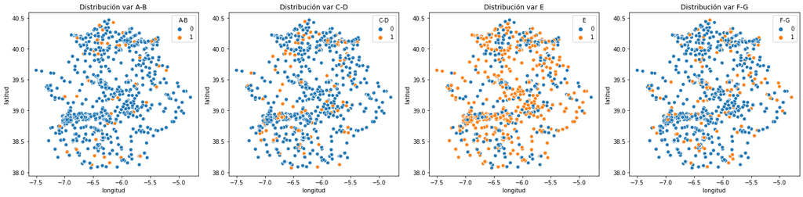

```python
# Representación de la distribución de las certificaciones energéticas por coordenadas

fig, axes = plt.subplots(1, 4, figsize=(20, 5))
axes = axes.flatten()

for i, column in enumerate(Y.columns):
    sns.scatterplot(x='longitud', y='latitud',
                    data=XY, hue=column, ax=axes[i])
    axes[i].set_title('Distribución var {}'.format(column))

plt.tight_layout()
plt.show()
```

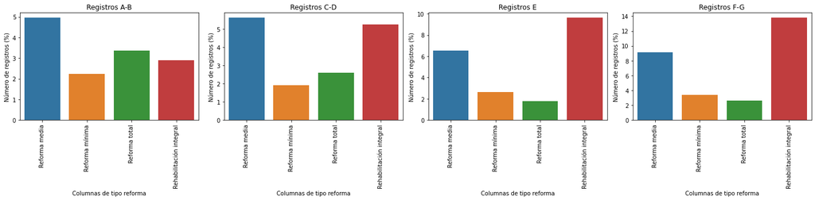

```python
XY_graph = XY[['Reforma media',	'Reforma mínima',	'Reforma total',	'Rehabilitación integral'] + ['A-B', 'C-D', 'E', 'F-G']]

# Crear una figura y ejes para cada columna
fig, axes = plt.subplots(1, 4, figsize=(20, 5))
axes = axes.flatten()

for j, columna_cert in enumerate(XY_graph.columns[-4:]):
    ax = axes[j]
    registros = []

    # Iterar sobre las columnas de m2 y graficar el número de registros con valor 1
    for i, columna_m2 in enumerate(XY_graph.columns[:-4]):
        # Filtrar los registros con valor 1 en la columna de m2 y la columna objetivo
        registros.append(XY_graph[(XY_graph[columna_m2] == 1) & (XY_graph[columna_cert] == 1)].shape[0] / XY_graph[XY_graph[columna_cert] == 1].shape[0] * 100)

    # Graficar el número de registros con valor 1 en cada columna objetivo
    sns.barplot(x=XY_graph.columns[:-4], y=registros, ax=ax)

    ax.set_title('Registros {}'.format(columna_cert))
    ax.set_xlabel('Columnas de tipo reforma')
    ax.set_ylabel('Número de registros (%)')
    ax.set_xticklabels(ax.get_xticklabels(), rotation=90)

plt.tight_layout()
plt.show()
```

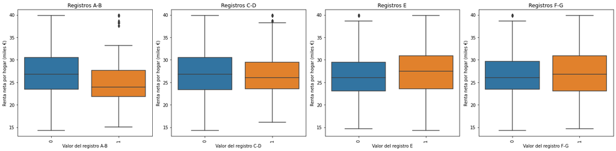

```python
XY_graph = XY[['renta_neta_por_hogar'] + ['A-B', 'C-D', 'E', 'F-G']]

# Crear una figura y ejes para cada columna
fig, axes = plt.subplots(1, 4, figsize=(20, 5))
axes = axes.flatten()

for i, columna_cert in enumerate(XY_graph.columns[-4:]):
    ax = axes[i]

    # Graficar el número de registros con valor 1 en cada columna objetivo
    sns.boxplot(y='renta_neta_por_hogar', x=columna_cert, data=XY_graph, ax=ax)

    ax.set_title('Registros {}'.format(columna_cert))
    ax.set_xlabel('Valor del registro {}'.format(columna_cert))
    ax.set_ylabel('Renta neta por hogar (miles €)')
    ax.set_xticklabels(ax.get_xticklabels(), rotation=90)

plt.tight_layout()
plt.show()
```

```python
###############################################
# Gráficas con valores X normalizados
###############################################
# Eliminamos la columna ref_cat dado que no se utilizará en el modelo
XY.drop(['ref_cat','A', 'B', 'C', 'D', 'F', 'G'], axis=1, inplace = True)

Y = XY[['A-B', 'C-D', 'E', 'F-G']]
X = XY[XY.columns.difference(Y.columns)]
X_normalizado = (X-X.mean())/X.std()
X_normalizado[:2]
```

|  | 0 < año <= 1981 | 1 < m2 <= 56 | 110 < m2 <= 1245 | 1981 < año <= 2005 | 2005 < año <= 2022 | 56 < m2 <= 72 | 72 < m2 <= 90 | 90 < m2 <= 110 | Almacén - Estacionamiento | Badajoz | Comercial | Cultural | Cáceres | Deportivo | Edificio singular | Industrial | Obras de urbanización y jardinería, suelos sin edificar | Ocio y Hostelería | Oficinas | Reforma media | Reforma mínima | Reforma total | Rehabilitación integral | Residencial | Sin reformar | ZC-C3 | ZC-C4 | ZC-D3 | ZC-E1 | … |
| --- | --- | --- | --- | --- | --- | --- | --- | --- | --- | --- | --- | --- | --- | --- | --- | --- | --- | --- | --- | --- | --- | --- | --- | --- | --- | --- | --- | --- | --- | --- |
| 0 | -0.676022 | -0.486735 | 1.974266 | -0.863909 | 1.691837 | -0.505738 | -0.50058 | -0.500031 | -0.027398 | 0.790024 | -0.015312 | -0.027823 | -0.790024 | -0.016774 | -0.008386 | -0.019966 | -0.012811 | -0.006847 | -0.016774 | -0.268866 | -0.163596 | -0.148379 | -0.318141 | 0.054858 | 0.510813 | -0.161163 | 0.33398 | -0.283419 | -0.026081 | … |
| 1 | -0.676022 | -0.486735 | 1.974266 | -0.863909 | 1.691837 | -0.505738 | -0.50058 | -0.500031 | -0.027398 | 0.790024 | -0.015312 | -0.027823 | -0.790024 | -0.016774 | -0.008386 | -0.019966 | -0.012811 | -0.006847 | -0.016774 | -0.268866 | -0.163596 | -0.148379 | -0.318141 | 0.054858 | 0.510813 | -0.161163 | 0.33398 | -0.283419 | -0.026081 | … |

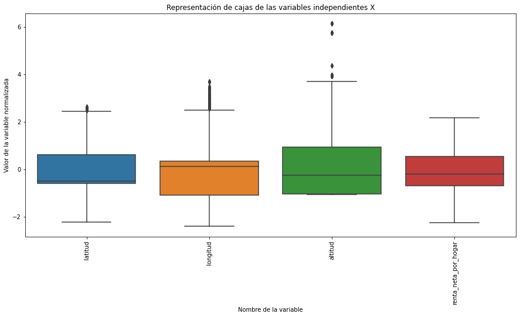

```python
plt.figure(figsize=(15,7))
ax = sns.boxplot(data=X_normalizado[['latitud','longitud','altitud', 'renta_neta_por_hogar']])
ax.set_xticklabels(ax.get_xticklabels(),rotation=90)
plt.title(u'Representación de cajas de las variables independientes X')
plt.ylabel('Valor de la variable normalizada')
_ = plt.xlabel('Nombre de la variable')
```

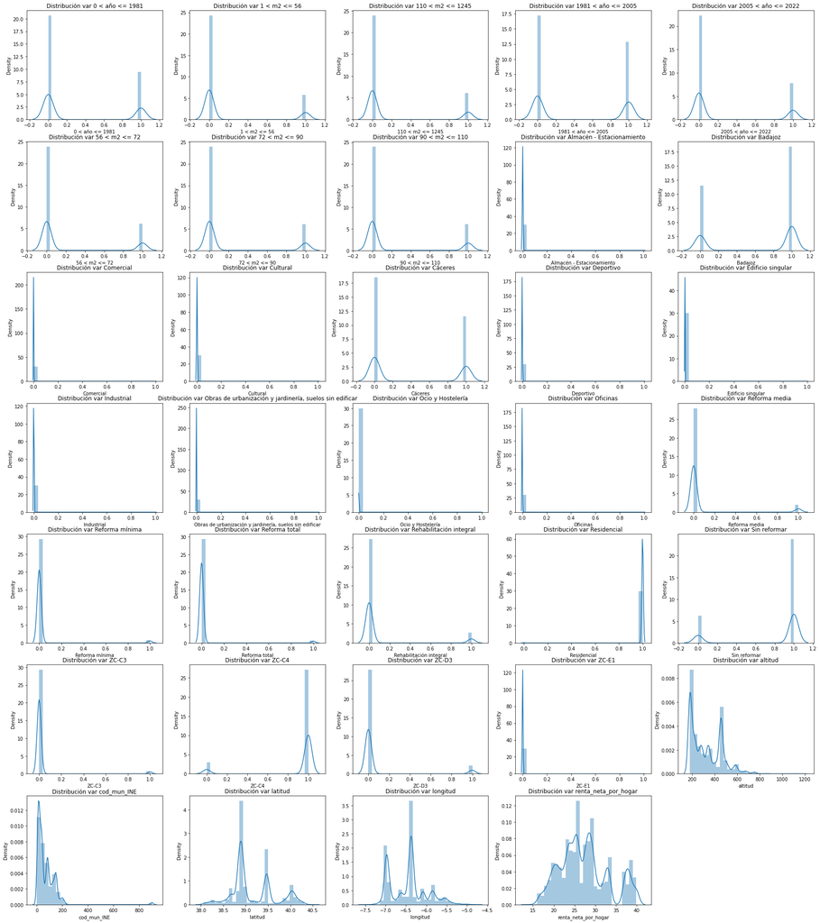

```python
plt.figure(figsize=(30,35))
n = 0
for i, column in enumerate(X.columns):
    n+=1
    plt.subplot(7, 5, n)
    sns.distplot(X[column], bins=30)
    plt.title('Distribución var {}'.format(column))
plt.show()
```

```python
XY.describe()
```

|  | cod_mun_INE | longitud | latitud | altitud | renta_neta_por_hogar | Reforma media | Reforma mínima | Reforma total | Rehabilitación integral | Sin reformar | Badajoz | Cáceres | ZC-C3 | ZC-C4 | ZC-D3 | ZC-E1 | Almacén - Estacionamiento | Comercial | Cultural | Deportivo | Edificio singular | Industrial | Obras de urbanización y jardinería, suelos sin edificar | Ocio y Hostelería | Oficinas | Residencial | E | A-B | C-D | … |
| --- | --- | --- | --- | --- | --- | --- | --- | --- | --- | --- | --- | --- | --- | --- | --- | --- | --- | --- | --- | --- | --- | --- | --- | --- | --- | --- | --- | --- | --- | --- |
| count | 42660.000000 | 42660.000000 | 42660.000000 | 42660.000000 | 42660.000000 | 42660.000000 | 42660.000000 | 42660.000000 | 42660.000000 | 42660.000000 | 42660.000000 | 42660.000000 | 42660.000000 | 42660.000000 | 42660.000000 | 42660.000000 | 42660.000000 | 42660.000000 | 42660.000000 | 42660.000000 | 42660.000000 | 42660.000000 | 42660.000000 | 42660.000000 | 42660.000000 | 42660.000000 | 42660.000000 | 42660.000000 | 42660.000000 | … |
| mean | 70.311814 | -6.435394 | 39.163415 | 327.885373 | 27.295406 | 0.067417 | 0.026067 | 0.021542 | 0.091913 | 0.793061 | 0.615706 | 0.384294 | 0.025316 | 0.899648 | 0.074355 | 0.000680 | 0.000750 | 0.000234 | 0.000774 | 0.000281 | 0.000070 | 0.000398 | 0.000164 | 0.000047 | 0.000281 | 0.997000 | 0.607361 | 0.050188 | 0.177192 | … |
| std | 85.514982 | 0.445382 | 0.493922 | 138.240297 | 5.772527 | 0.250745 | 0.159335 | 0.145186 | 0.288906 | 0.405116 | 0.486434 | 0.486434 | 0.157086 | 0.300472 | 0.262351 | 0.026064 | 0.027378 | 0.015309 | 0.027802 | 0.016770 | 0.008386 | 0.019959 | 0.012809 | 0.006847 | 0.016770 | 0.054695 | 0.488343 | 0.218334 | 0.381835 | … |
| min | 1.000000 | -7.501654 | 38.065023 | 181.000000 | 14.302000 | 0.000000 | 0.000000 | 0.000000 | 0.000000 | 0.000000 | 0.000000 | 0.000000 | 0.000000 | 0.000000 | 0.000000 | 0.000000 | 0.000000 | 0.000000 | 0.000000 | 0.000000 | 0.000000 | 0.000000 | 0.000000 | 0.000000 | 0.000000 | 0.000000 | 0.000000 | 0.000000 | 0.000000 | … |
| 25% | 15.000000 | -6.913293 | 38.872296 | 184.000000 | 23.361000 | 0.000000 | 0.000000 | 0.000000 | 0.000000 | 1.000000 | 0.000000 | 0.000000 | 0.000000 | 1.000000 | 0.000000 | 0.000000 | 0.000000 | 0.000000 | 0.000000 | 0.000000 | 0.000000 | 0.000000 | 0.000000 | 0.000000 | 0.000000 | 1.000000 | 0.000000 | 0.000000 | 0.000000 | … |
| 50% | 37.000000 | -6.381696 | 38.922885 | 293.000000 | 26.197000 | 0.000000 | 0.000000 | 0.000000 | 0.000000 | 1.000000 | 1.000000 | 0.000000 | 0.000000 | 1.000000 | 0.000000 | 0.000000 | 0.000000 | 0.000000 | 0.000000 | 0.000000 | 0.000000 | 0.000000 | 0.000000 | 0.000000 | 0.000000 | 1.000000 | 1.000000 | 0.000000 | 0.000000 | … |
| 75% | 97.000000 | -6.275400 | 39.472403 | 457.000000 | 30.499000 | 0.000000 | 0.000000 | 0.000000 | 0.000000 | 1.000000 | 1.000000 | 1.000000 | 0.000000 | 1.000000 | 0.000000 | 0.000000 | 0.000000 | 0.000000 | 0.000000 | 0.000000 | 0.000000 | 0.000000 | 0.000000 | 0.000000 | 0.000000 | 1.000000 | 1.000000 | 0.000000 | 0.000000 | … |
| max | 905.000000 | -4.790068 | 40.466477 | 1176.000000 | 39.879000 | 1.000000 | 1.000000 | 1.000000 | 1.000000 | 1.000000 | 1.000000 | 1.000000 | 1.000000 | 1.000000 | 1.000000 | 1.000000 | 1.000000 | 1.000000 | 1.000000 | 1.000000 | 1.000000 | 1.000000 | 1.000000 | 1.000000 | 1.000000 | 1.000000 | 1.000000 | 1.000000 | 1.000000 | … |

# Análisis de correlaciones

```python
Y = XY[['A-B', 'C-D', 'E', 'F-G']]
X = XY[XY.columns.difference(Y.columns)]

# Variables a analizar (variables categóricas)
variables = X.columns.tolist()[:-5]
variables_objetivo = Y.columns.tolist()
```

```python
# Crear un diccionario para almacenar las tablas de contingencia por columna objetivo
tablas_contingencia_dict = {columna: [] for columna in variables_objetivo}

# Realizar el análisis de correlación para cada variable y cada columna objetivo
for variable in variables:
    for columna in variables_objetivo:
        # Crear la tabla de contingencia
        contingency_table = pd.crosstab(XY[variable], XY[columna])

        # Agregar la tabla de contingencia a la lista correspondiente en el diccionario
        tablas_contingencia_dict[columna].append(contingency_table)

# Concatenar las tablas de contingencia en columnas
dfs_concat = {columna: pd.concat(tablas, keys=variables, axis=1) for columna, tablas in tablas_contingencia_dict.items()}

# Mostrar los DataFrames concatenados
for columna, df_concat in dfs_concat.items():
    print('Columna objetivo:', columna)
    display(df_concat)
    print('\n')
```

```
Columna objetivo: A-B
```

| A-B | 0 < año <= 1981 0 | 0 < año <= 1981 1 | 1 < m2 <= 56 0 | 1 < m2 <= 56 1 | 110 < m2 <= 1245 0 | 110 < m2 <= 1245 1 | 1981 < año <= 2005 0 | 1981 < año <= 2005 1 | 2005 < año <= 2022 0 | 2005 < año <= 2022 1 | 56 < m2 <= 72 0 | 56 < m2 <= 72 1 | 72 < m2 <= 90 0 | 72 < m2 <= 90 1 | 90 < m2 <= 110 0 | 90 < m2 <= 110 1 | Almacén - Estacionamiento 0 | Almacén - Estacionamiento 1 | Badajoz 0 | Badajoz 1 | Comercial 0 | Comercial 1 | Cultural 0 | Cultural 1 | Cáceres 0 | Cáceres 1 | Deportivo 0 | Deportivo 1 | Edificio singular 0 | … |
| --- | --- | --- | --- | --- | --- | --- | --- | --- | --- | --- | --- | --- | --- | --- | --- | --- | --- | --- | --- | --- | --- | --- | --- | --- | --- | --- | --- | --- | --- | --- |
| 0 | 27405 | 1874 | 32836 | 1653 | 32409 | 1541 | 22564 | 1864 | 31069 | 546 | 32165 | 1806 | 32355 | 1757 | 32320 | 1807 | 40492 | 2136 | 15591 | 803 | 40509 | 2141 | 40490 | 2137 | 24928 | 1338 | 40507 | 2141 | 40516 | … |
| 1 | 13114 | 267 | 7683 | 488 | 8110 | 600 | 17955 | 277 | 9450 | 1595 | 8354 | 335 | 8164 | 384 | 8199 | 334 | 27 | 5 | 24928 | 1338 | 10 | 0 | 29 | 4 | 15591 | 803 | 12 | 0 | 3 | … |

```
Columna objetivo: C-D
```

| C-D | 0 < año <= 1981 0 | 0 < año <= 1981 1 | 1 < m2 <= 56 0 | 1 < m2 <= 56 1 | 110 < m2 <= 1245 0 | 110 < m2 <= 1245 1 | 1981 < año <= 2005 0 | 1981 < año <= 2005 1 | 2005 < año <= 2022 0 | 2005 < año <= 2022 1 | 56 < m2 <= 72 0 | 56 < m2 <= 72 1 | 72 < m2 <= 90 0 | 72 < m2 <= 90 1 | 90 < m2 <= 110 0 | 90 < m2 <= 110 1 | Almacén - Estacionamiento 0 | Almacén - Estacionamiento 1 | Badajoz 0 | Badajoz 1 | Comercial 0 | Comercial 1 | Cultural 0 | Cultural 1 | Cáceres 0 | Cáceres 1 | Deportivo 0 | Deportivo 1 | Edificio singular 0 | … |
| --- | --- | --- | --- | --- | --- | --- | --- | --- | --- | --- | --- | --- | --- | --- | --- | --- | --- | --- | --- | --- | --- | --- | --- | --- | --- | --- | --- | --- | --- | --- |
| 0 | 22894 | 6385 | 28432 | 6057 | 27987 | 5963 | 19721 | 4707 | 27589 | 4026 | 28348 | 5623 | 27809 | 6303 | 27834 | 6293 | 35079 | 7549 | 13556 | 2838 | 35096 | 7554 | 35087 | 7540 | 21545 | 4721 | 35097 | 7551 | 35099 | … |
| 1 | 12207 | 1174 | 6669 | 1502 | 7114 | 1596 | 15380 | 2852 | 7512 | 3533 | 6753 | 1936 | 7292 | 1256 | 7267 | 1266 | 22 | 10 | 21545 | 4721 | 5 | 5 | 14 | 19 | 13556 | 2838 | 4 | 8 | 2 | … |

```
Columna objetivo: E
```

| E | 0 < año <= 1981 0 | 0 < año <= 1981 1 | 1 < m2 <= 56 0 | 1 < m2 <= 56 1 | 110 < m2 <= 1245 0 | 110 < m2 <= 1245 1 | 1981 < año <= 2005 0 | 1981 < año <= 2005 1 | 2005 < año <= 2022 0 | 2005 < año <= 2022 1 | 56 < m2 <= 72 0 | 56 < m2 <= 72 1 | 72 < m2 <= 90 0 | 72 < m2 <= 90 1 | 90 < m2 <= 110 0 | 90 < m2 <= 110 1 | Almacén - Estacionamiento 0 | Almacén - Estacionamiento 1 | Badajoz 0 | Badajoz 1 | Comercial 0 | Comercial 1 | Cultural 0 | Cultural 1 | Cáceres 0 | Cáceres 1 | Deportivo 0 | Deportivo 1 | Edificio singular 0 | … |
| --- | --- | --- | --- | --- | --- | --- | --- | --- | --- | --- | --- | --- | --- | --- | --- | --- | --- | --- | --- | --- | --- | --- | --- | --- | --- | --- | --- | --- | --- | --- |
| 0 | 11760 | 17519 | 13270 | 21219 | 13255 | 20695 | 10831 | 13597 | 10911 | 20704 | 13110 | 20861 | 13613 | 20499 | 13755 | 20372 | 16731 | 25897 | 6671 | 9723 | 16743 | 25907 | 16725 | 25902 | 10079 | 16187 | 16742 | 25906 | 16748 | … |
| 1 | 4990 | 8391 | 3480 | 4691 | 3495 | 5215 | 5919 | 12313 | 5839 | 5206 | 3640 | 5049 | 3137 | 5411 | 2995 | 5538 | 19 | 13 | 10079 | 16187 | 7 | 3 | 25 | 8 | 6671 | 9723 | 8 | 4 | 2 | … |

```
Columna objetivo: F-G
```

| F-G | 0 < año <= 1981 0 | 0 < año <= 1981 1 | 1 < m2 <= 56 0 | 1 < m2 <= 56 1 | 110 < m2 <= 1245 0 | 110 < m2 <= 1245 1 | 1981 < año <= 2005 0 | 1981 < año <= 2005 1 | 2005 < año <= 2022 0 | 2005 < año <= 2022 1 | 56 < m2 <= 72 0 | 56 < m2 <= 72 1 | 72 < m2 <= 90 0 | 72 < m2 <= 90 1 | 90 < m2 <= 110 0 | 90 < m2 <= 110 1 | Almacén - Estacionamiento 0 | Almacén - Estacionamiento 1 | Badajoz 0 | Badajoz 1 | Comercial 0 | Comercial 1 | Cultural 0 | Cultural 1 | Cáceres 0 | Cáceres 1 | Deportivo 0 | Deportivo 1 | Edificio singular 0 | … |
| --- | --- | --- | --- | --- | --- | --- | --- | --- | --- | --- | --- | --- | --- | --- | --- | --- | --- | --- | --- | --- | --- | --- | --- | --- | --- | --- | --- | --- | --- | --- |
| 0 | 25778 | 3501 | 28929 | 5560 | 28199 | 5751 | 20168 | 4260 | 25276 | 6339 | 28290 | 5681 | 28559 | 5553 | 28472 | 5655 | 35582 | 7046 | 13364 | 3030 | 35602 | 7048 | 35579 | 7048 | 22246 | 4020 | 35598 | 7050 | 35608 | … |
| 1 | 9832 | 3549 | 6681 | 1490 | 7411 | 1299 | 15442 | 2790 | 10334 | 711 | 7320 | 1369 | 7051 | 1497 | 7138 | 1395 | 28 | 4 | 22246 | 4020 | 8 | 2 | 31 | 2 | 13364 | 3030 | 12 | 0 | 2 | … |

## Prueba exacta de Fisher

H0 = Las variables son independientes por lo que una variable no varía entre los distintos niveles de la otra variable.

H1 = Las variables son dependientes, una variable varía entre los distintos niveles de la otra variable.

alpha = 0.05

NOTA: Test válido para variables binomiales

```python
alpha = 0.05
resultados = []
# Realiza el análisis de correlación para cada variable y cada columna objetivo
for variable in variables:
    for columna in variables_objetivo:
        # Crea la tabla de contingencia
        contingency_table = pd.crosstab(XY[variable], XY[columna])

        # Realiza la prueba exacta de Fisher
        odds_ratio, p_value = fisher_exact(contingency_table)

        # Agrega los resultados a la lista
        resultados.append({'Variable': variable,
                           'Columna objetivo': columna,
                           'Odds ratio': odds_ratio,
                           'p-value': p_value})

# Crea un DataFrame con los resultados
fisher_tabla_resultados = pd.DataFrame(resultados)
fisher_tabla_resultados['p-valor <'+ str(alpha)] = fisher_tabla_resultados['p-value'].apply(lambda p_value: 1 if p_value < alpha else 0)

# Agrupa los resultados por columna objetivo
tabla_agrupada = fisher_tabla_resultados.groupby('Columna objetivo')

fisher_var_ind = {}
# Imprime la tabla agrupada
for columna, grupo in tabla_agrupada:
    print('Columna objetivo:', columna)
    display(grupo)
    print('\n')

    var_independientes_i = {columna: grupo[grupo['p-valor <'+ str(alpha)]== 1]['Variable'].tolist()}
    fisher_var_ind.update(var_independientes_i)
```

```
Columna objetivo: A-B
```

|  | Variable | Columna objetivo | Odds ratio | p-value | p-valor <0.05 |
| --- | --- | --- | --- | --- | --- |
| 0 | 0 < año <= 1981 | A-B | 0.297739 | 5.315674e-97 | 1 |
| 4 | 1 < m2 <= 56 | A-B | 1.261730 | 1.809206e-05 | 1 |
| 8 | 110 < m2 <= 1245 | A-B | 1.555942 | 6.969325e-18 | 1 |
| 12 | 1981 < año <= 2005 | A-B | 0.186752 | 2.355105e-206 | 1 |
| 16 | 2005 < año <= 2022 | A-B | 9.604251 | 0.000000e+00 | 1 |
| 20 | 56 < m2 <= 72 | A-B | 0.714194 | 1.142965e-08 | 1 |
| 24 | 72 < m2 <= 90 | A-B | 0.866159 | 1.264138e-02 | 1 |
| 28 | 90 < m2 <= 110 | A-B | 0.728616 | 8.496469e-08 | 1 |
| 32 | Almacén - Estacionamiento | A-B | 3.510542 | 2.060520e-02 | 1 |
| 36 | Badajoz | A-B | 1.042142 | 3.740623e-01 | 0 |
| 40 | Comercial | A-B | 0.000000 | 1.000000e+00 | 0 |
| 44 | Cultural | A-B | 2.613396 | 8.160278e-02 | 0 |
| 48 | Cáceres | A-B | 0.959562 | 3.740623e-01 | 0 |
| 52 | Deportivo | A-B | 0.000000 | 1.000000e+00 | 0 |
| 56 | Edificio singular | A-B | 0.000000 | 1.000000e+00 | 0 |
| 60 | Industrial | A-B | 1.182915 | 5.833508e-01 | 0 |
| 64 | Obras de urbanización y jardinería, suelos sin... | A-B | 0.000000 | 1.000000e+00 | 0 |
| 68 | Ocio y Hostelería | A-B | 18.933645 | 9.785739e-02 | 0 |
| 72 | Oficinas | A-B | 3.787658 | 1.190808e-01 | 0 |
| 76 | Reforma media | A-B | 0.709851 | 4.705585e-04 | 1 |
| 80 | Reforma mínima | A-B | 0.850418 | 2.968993e-01 | 0 |
| 84 | Reforma total | A-B | 1.629944 | 2.257416e-04 | 1 |
| 88 | Rehabilitación integral | A-B | 0.283305 | 4.146020e-32 | 1 |
| 92 | Residencial | A-B | 0.465910 | 1.365040e-02 | 1 |
| 96 | Sin reformar | A-B | 1.718209 | 6.945156e-19 | 1 |
| 100 | ZC-C3 | A-B | 2.717535 | 1.040812e-20 | 1 |
| 104 | ZC-C4 | A-B | 0.528116 | 1.828188e-23 | 1 |
| 108 | ZC-D3 | A-B | 1.529213 | 2.162615e-08 | 1 |
| 112 | ZC-E1 | A-B | 0.675751 | 1.000000e+00 | 0 |

```
Columna objetivo: C-D
```

|  | Variable | Columna objetivo | Odds ratio | p-value | p-valor <0.05 |
| --- | --- | --- | --- | --- | --- |
| 1 | 0 < año <= 1981 | C-D | 0.344842 | 8.205658e-260 | 1 |
| 5 | 1 < m2 <= 56 | C-D | 1.057205 | 8.185873e-02 | 0 |
| 9 | 110 < m2 <= 1245 | C-D | 1.052957 | 9.864804e-02 | 0 |
| 13 | 1981 < año <= 2005 | C-D | 0.776923 | 1.910909e-22 | 1 |
| 17 | 2005 < año <= 2022 | C-D | 3.222925 | 0.000000e+00 | 1 |
| 21 | 56 < m2 <= 72 | C-D | 1.445316 | 2.801841e-34 | 1 |
| 25 | 72 < m2 <= 90 | C-D | 0.759943 | 8.542646e-17 | 1 |
| 29 | 90 < m2 <= 110 | C-D | 0.770542 | 2.459427e-15 | 1 |
| 33 | Almacén - Estacionamiento | C-D | 2.112200 | 6.023612e-02 | 0 |
| 37 | Badajoz | C-D | 1.046663 | 8.300441e-02 | 0 |
| 41 | Comercial | C-D | 4.646015 | 1.996359e-02 | 1 |
| 45 | Cultural | C-D | 6.315394 | 3.247279e-07 | 1 |
| 49 | Cáceres | C-D | 0.955418 | 8.300441e-02 | 0 |
| 53 | Deportivo | C-D | 9.295987 | 2.423992e-04 | 1 |
| 57 | Edificio singular | C-D | 2.321977 | 4.429562e-01 | 0 |
| 61 | Industrial | C-D | 0.995056 | 1.000000e+00 | 0 |
| 65 | Obras de urbanización y jardinería, suelos sin... | C-D | 6.194220 | 2.187654e-02 | 1 |
| 69 | Ocio y Hostelería | C-D | 4.644086 | 3.229900e-01 | 0 |
| 73 | Oficinas | C-D | 0.928702 | 1.000000e+00 | 0 |
| 77 | Reforma media | C-D | 0.793589 | 1.351028e-05 | 1 |
| 81 | Reforma mínima | C-D | 0.690361 | 2.004253e-05 | 1 |
| 85 | Reforma total | C-D | 1.274167 | 3.415135e-03 | 1 |
| 89 | Rehabilitación integral | C-D | 0.496697 | 7.809606e-44 | 1 |
| 93 | Residencial | C-D | 0.303252 | 3.269617e-10 | 1 |
| 97 | Sin reformar | C-D | 1.534640 | 6.091993e-38 | 1 |
| 101 | ZC-C3 | C-D | 0.839851 | 4.346645e-02 | 1 |
| 105 | ZC-C4 | C-D | 1.060645 | 1.768511e-01 | 0 |
| 109 | ZC-D3 | C-D | 0.985907 | 7.903750e-01 | 0 |
| 113 | ZC-E1 | C-D | 0.742841 | 8.076109e-01 | 0 |

```
Columna objetivo: E
```

|  | Variable | Columna objetivo | Odds ratio | p-value | p-valor <0.05 |
| --- | --- | --- | --- | --- | --- |
| 2 | 0 < año <= 1981 | E | 1.128785 | 1.683000e-08 | 1 |
| 6 | 1 < m2 <= 56 | E | 0.843009 | 9.271579e-12 | 1 |
| 10 | 110 < m2 <= 1245 | E | 0.955700 | 6.509155e-02 | 0 |
| 14 | 1981 < año <= 2005 | E | 1.657071 | 2.719630e-137 | 1 |
| 18 | 2005 < año <= 2022 | E | 0.469868 | 2.190335e-249 | 1 |
| 22 | 56 < m2 <= 72 | E | 0.871709 | 2.123628e-08 | 1 |
| 26 | 72 < m2 <= 90 | E | 1.145471 | 5.394937e-08 | 1 |
| 30 | 90 < m2 <= 110 | E | 1.248484 | 8.569816e-19 | 1 |
| 34 | Almacén - Estacionamiento | E | 0.442041 | 2.819522e-02 | 1 |
| 38 | Badajoz | E | 1.101893 | 1.940548e-06 | 1 |
| 42 | Comercial | E | 0.276974 | 5.629644e-02 | 0 |
| 46 | Cultural | E | 0.206625 | 3.961173e-05 | 1 |
| 50 | Cáceres | E | 0.907529 | 1.940548e-06 | 1 |
| 54 | Deportivo | E | 0.323130 | 7.339299e-02 | 0 |
| 58 | Edificio singular | E | 0.323208 | 5.654676e-01 | 0 |
| 62 | Industrial | E | 0.727182 | 6.206845e-01 | 0 |
| 66 | Obras de urbanización y jardinería, suelos sin... | E | 0.107710 | 1.700916e-02 | 1 |
| 70 | Ocio y Hostelería | E | 0.000000 | 1.541602e-01 | 0 |
| 74 | Oficinas | E | 1.293028 | 7.746376e-01 | 0 |
| 78 | Reforma media | E | 0.928488 | 6.035164e-02 | 0 |
| 82 | Reforma mínima | E | 1.010187 | 8.764414e-01 | 0 |
| 86 | Reforma total | E | 0.653042 | 2.310694e-10 | 1 |
| 90 | Rehabilitación integral | E | 1.139536 | 1.708225e-04 | 1 |
| 94 | Residencial | E | 2.673970 | 5.003993e-08 | 1 |
| 98 | Sin reformar | E | 1.017976 | 4.703197e-01 | 0 |
| 102 | ZC-C3 | E | 0.791263 | 1.714098e-04 | 1 |
| 106 | ZC-C4 | E | 1.366815 | 8.064995e-22 | 1 |
| 110 | ZC-D3 | E | 0.720841 | 1.590080e-18 | 1 |
| 114 | ZC-E1 | E | 1.228458 | 7.051799e-01 | 0 |

```
Columna objetivo: F-G
```

|  | Variable | Columna objetivo | Odds ratio | p-value | p-valor <0.05 |
| --- | --- | --- | --- | --- | --- |
| 3 | 0 < año <= 1981 | F-G | 2.657794 | 2.658954e-291 | 1 |
| 7 | 1 < m2 <= 56 | F-G | 1.160389 | 4.809539e-06 | 1 |
| 11 | 110 < m2 <= 1245 | F-G | 0.859454 | 4.717746e-06 | 1 |
| 15 | 1981 < año <= 2005 | F-G | 0.855370 | 3.847615e-09 | 1 |
| 19 | 2005 < año <= 2022 | F-G | 0.274340 | 9.597907e-282 | 1 |
| 23 | 56 < m2 <= 72 | F-G | 0.931323 | 3.011554e-02 | 1 |
| 27 | 72 < m2 <= 90 | F-G | 1.091909 | 6.227172e-03 | 1 |
| 31 | 90 < m2 <= 110 | F-G | 0.983973 | 6.365552e-01 | 0 |
| 35 | Almacén - Estacionamiento | F-G | 0.721422 | 8.108170e-01 | 0 |
| 39 | Badajoz | F-G | 0.797018 | 1.332290e-17 | 1 |
| 43 | Comercial | F-G | 1.262841 | 6.748023e-01 | 0 |
| 47 | Cultural | F-G | 0.325684 | 1.550241e-01 | 0 |
| 51 | Cáceres | F-G | 1.254677 | 1.332290e-17 | 1 |
| 55 | Deportivo | F-G | 0.000000 | 2.365826e-01 | 0 |
| 59 | Edificio singular | F-G | 2.525748 | 4.183693e-01 | 0 |
| 63 | Industrial | F-G | 1.554488 | 5.079180e-01 | 0 |
| 67 | Obras de urbanización y jardinería, suelos sin... | F-G | 2.020715 | 3.262472e-01 | 0 |
| 71 | Ocio y Hostelería | F-G | 0.000000 | 1.000000e+00 | 0 |
| 75 | Oficinas | F-G | 0.000000 | 2.365826e-01 | 0 |
| 79 | Reforma media | F-G | 1.509950 | 1.488724e-17 | 1 |
| 83 | Reforma mínima | F-G | 1.411669 | 6.457175e-06 | 1 |
| 87 | Reforma total | F-G | 1.289350 | 3.005698e-03 | 1 |
| 91 | Rehabilitación integral | F-G | 1.768403 | 9.612567e-44 | 1 |
| 95 | Residencial | F-G | 1.492999 | 1.536936e-01 | 0 |
| 99 | Sin reformar | F-G | 0.576383 | 4.690051e-74 | 1 |
| 103 | ZC-C3 | F-G | 1.059298 | 4.805592e-01 | 0 |
| 107 | ZC-C4 | F-G | 0.731996 | 3.382127e-14 | 1 |
| 111 | ZC-D3 | F-G | 1.462864 | 2.503978e-16 | 1 |
| 115 | ZC-E1 | F-G | 1.052342 | 8.062517e-01 | 0 |

## Chi cuadrado

```python
alpha = 0.05
resultados = []

# Realiza el análisis de correlación para cada variable y cada columna objetivo
for variable in variables:
    for columna in variables_objetivo:
        # Crea la tabla de contingencia
        contingency_table = pd.crosstab(XY[variable], XY[columna])

        # Realiza la prueba de chi cuadrado
        chi2, p_value, _, _ = chi2_contingency(contingency_table)

        # Agrega los resultados a la lista
        resultados.append({'Variable': variable,
                           'Columna objetivo': columna,
                           'Chi-square': chi2,
                           'p-value': p_value})

# Crea un DataFrame con los resultados
chi2_tabla_resultados = pd.DataFrame(resultados)
chi2_tabla_resultados['p-valor <'+ str(alpha)] = chi2_tabla_resultados['p-value'].apply(lambda p_value: 1 if p_value < alpha else 0)

# Agrupa los resultados por columna objetivo
tabla_agrupada = chi2_tabla_resultados.groupby('Columna objetivo')

# Imprime la tabla agrupada
chi2_var_ind = {}
for columna, grupo in tabla_agrupada:
    print('Columna objetivo:', columna)
    display(grupo)
    print('\n')

    var_independientes_i = {columna: grupo[grupo['p-valor <'+ str(alpha)]== 1]['Variable'].tolist()}
    chi2_var_ind.update(var_independientes_i)
```

```
Columna objetivo: A-B
```

|  | Variable | Columna objetivo | Chi-square | p-value | p-valor <0.05 |
| --- | --- | --- | --- | --- | --- |
| 0 | 0 < año <= 1981 | A-B | 372.934563 | 4.297892e-83 | 1 |
| 4 | 1 < m2 <= 56 | A-B | 19.033202 | 1.284636e-05 | 1 |
| 8 | 110 < m2 <= 1245 | A-B | 79.785273 | 4.173923e-19 | 1 |
| 12 | 1981 < año <= 2005 | A-B | 816.678751 | 1.275989e-179 | 1 |
| 16 | 2005 < año <= 2022 | A-B | 2772.963840 | 0.000000e+00 | 1 |
| 20 | 56 < m2 <= 72 | A-B | 30.670968 | 3.057050e-08 | 1 |
| 24 | 72 < m2 <= 90 | A-B | 6.078467 | 1.368395e-02 | 1 |
| 28 | 90 < m2 <= 110 | A-B | 27.010436 | 2.023599e-07 | 1 |
| 32 | Almacén - Estacionamiento | A-B | 5.494637 | 1.907489e-02 | 1 |
| 36 | Badajoz | A-B | 0.772090 | 3.795712e-01 | 0 |
| 40 | Comercial | A-B | 0.000007 | 9.978326e-01 | 0 |
| 44 | Cultural | A-B | 2.162826 | 1.413845e-01 | 0 |
| 48 | Cáceres | A-B | 0.772090 | 3.795712e-01 | 0 |
| 52 | Deportivo | A-B | 0.018283 | 8.924435e-01 | 0 |
| 56 | Edificio singular | A-B | 0.000000 | 1.000000e+00 | 0 |
| 60 | Industrial | A-B | 0.000000 | 1.000000e+00 | 0 |
| 64 | Obras de urbanización y jardinería, suelos sin... | A-B | 0.000000 | 1.000000e+00 | 0 |
| 68 | Ocio y Hostelería | A-B | 1.675181 | 1.955660e-01 | 0 |
| 72 | Oficinas | A-B | 1.409346 | 2.351649e-01 | 0 |
| 76 | Reforma media | A-B | 11.198937 | 8.184419e-04 | 1 |
| 80 | Reforma mínima | A-B | 1.034648 | 3.090695e-01 | 0 |
| 84 | Reforma total | A-B | 15.024913 | 1.061012e-04 | 1 |
| 88 | Rehabilitación integral | A-B | 106.242647 | 6.523748e-25 | 1 |
| 92 | Residencial | A-B | 6.068710 | 1.375974e-02 | 1 |
| 96 | Sin reformar | A-B | 71.575790 | 2.668104e-17 | 1 |
| 100 | ZC-C3 | A-B | 116.011003 | 4.726668e-27 | 1 |
| 104 | ZC-C4 | A-B | 115.545354 | 5.977621e-27 | 1 |
| 108 | ZC-D3 | A-B | 34.317841 | 4.680712e-09 | 1 |
| 112 | ZC-E1 | A-B | 0.000000 | 1.000000e+00 | 0 |

```
Columna objetivo: C-D
```

|  | Variable | Columna objetivo | Chi-square | p-value | p-valor <0.05 |
| --- | --- | --- | --- | --- | --- |
| 1 | 0 < año <= 1981 | C-D | 1069.205882 | 1.628909e-234 | 1 |
| 5 | 1 < m2 <= 56 | C-D | 2.990370 | 8.376102e-02 | 0 |
| 9 | 110 < m2 <= 1245 | C-D | 2.692116 | 1.008458e-01 | 0 |
| 13 | 1981 < año <= 2005 | C-D | 93.902654 | 3.314294e-22 | 1 |
| 17 | 2005 < año <= 2022 | C-D | 2079.749086 | 0.000000e+00 | 1 |
| 21 | 56 < m2 <= 72 | C-D | 155.356589 | 1.170223e-35 | 1 |
| 25 | 72 < m2 <= 90 | C-D | 66.865337 | 2.907017e-16 | 1 |
| 29 | 90 < m2 <= 110 | C-D | 60.548188 | 7.179914e-15 | 1 |
| 33 | Almacén - Estacionamiento | C-D | 3.146303 | 7.609921e-02 | 0 |
| 37 | Badajoz | C-D | 2.994293 | 8.355836e-02 | 0 |
| 41 | Comercial | C-D | 5.105928 | 2.384422e-02 | 1 |
| 45 | Cultural | C-D | 33.300023 | 7.898172e-09 | 1 |
| 49 | Cáceres | C-D | 2.994293 | 8.355836e-02 | 0 |
| 53 | Deportivo | C-D | 16.509939 | 4.839571e-05 | 1 |
| 57 | Edificio singular | C-D | 0.000000 | 1.000000e+00 | 0 |
| 61 | Industrial | C-D | 0.000000 | 1.000000e+00 | 0 |
| 65 | Obras de urbanización y jardinería, suelos sin... | C-D | 5.003990 | 2.528896e-02 | 1 |
| 69 | Ocio y Hostelería | C-D | 0.072723 | 7.874131e-01 | 0 |
| 73 | Oficinas | C-D | 0.000000 | 1.000000e+00 | 0 |
| 77 | Reforma media | C-D | 18.088777 | 2.108405e-05 | 1 |
| 81 | Reforma mínima | C-D | 16.821544 | 4.106445e-05 | 1 |
| 85 | Reforma total | C-D | 8.642687 | 3.283768e-03 | 1 |
| 89 | Rehabilitación integral | C-D | 170.228498 | 6.595693e-39 | 1 |
| 93 | Residencial | C-D | 47.791689 | 4.739971e-12 | 1 |
| 97 | Sin reformar | C-D | 156.553567 | 6.407702e-36 | 1 |
| 101 | ZC-C3 | C-D | 4.029214 | 4.471876e-02 | 1 |
| 105 | ZC-C4 | C-D | 1.830245 | 1.760986e-01 | 0 |
| 109 | ZC-D3 | C-D | 0.072014 | 7.884272e-01 | 0 |
| 113 | ZC-E1 | C-D | 0.096507 | 7.560621e-01 | 0 |

```
Columna objetivo: E
```

|  | Variable | Columna objetivo | Chi-square | p-value | p-valor <0.05 |
| --- | --- | --- | --- | --- | --- |
| 2 | 0 < año <= 1981 | E | 31.680799 | 1.817099e-08 | 1 |
| 6 | 1 < m2 <= 56 | E | 46.702606 | 8.261906e-12 | 1 |
| 10 | 110 < m2 <= 1245 | E | 3.367584 | 6.649118e-02 | 0 |
| 14 | 1981 < año <= 2005 | E | 616.698450 | 3.906927e-136 | 1 |
| 18 | 2005 < año <= 2022 | E | 1155.430659 | 2.962193e-253 | 1 |
| 22 | 56 < m2 <= 72 | E | 31.464557 | 2.031141e-08 | 1 |
| 26 | 72 < m2 <= 90 | E | 29.365184 | 5.994497e-08 | 1 |
| 30 | 90 < m2 <= 110 | E | 77.370331 | 1.417283e-18 | 1 |
| 34 | Almacén - Estacionamiento | E | 4.620143 | 3.159861e-02 | 1 |
| 38 | Badajoz | E | 22.663648 | 1.929846e-06 | 1 |
| 42 | Comercial | E | 2.778083 | 9.556251e-02 | 0 |
| 46 | Cultural | E | 16.943818 | 3.850249e-05 | 1 |
| 50 | Cáceres | E | 22.663648 | 1.929846e-06 | 1 |
| 54 | Deportivo | E | 2.717613 | 9.924634e-02 | 0 |
| 58 | Edificio singular | E | 0.145011 | 7.033495e-01 | 0 |
| 62 | Industrial | E | 0.168007 | 6.818892e-01 | 0 |
| 66 | Obras de urbanización y jardinería, suelos sin... | E | 4.536064 | 3.318781e-02 | 1 |
| 70 | Ocio y Hostelería | E | 1.071083 | 3.007010e-01 | 0 |
| 74 | Oficinas | E | 0.015662 | 9.004079e-01 | 0 |
| 78 | Reforma media | E | 3.493280 | 6.161837e-02 | 0 |
| 82 | Reforma mínima | E | 0.017322 | 8.952918e-01 | 0 |
| 86 | Reforma total | E | 40.911967 | 1.592430e-10 | 1 |
| 90 | Rehabilitación integral | E | 14.002379 | 1.825795e-04 | 1 |
| 94 | Residencial | E | 30.052444 | 4.205182e-08 | 1 |
| 98 | Sin reformar | E | 0.513446 | 4.736511e-01 | 0 |
| 102 | ZC-C3 | E | 14.078830 | 1.753058e-04 | 1 |
| 106 | ZC-C4 | E | 93.222552 | 4.673259e-22 | 1 |
| 110 | ZC-D3 | E | 78.233065 | 9.157282e-19 | 1 |
| 114 | ZC-E1 | E | 0.113726 | 7.359418e-01 | 0 |

```
Columna objetivo: F-G
```

|  | Variable | Columna objetivo | Chi-square | p-value | p-valor <0.05 |
| --- | --- | --- | --- | --- | --- |
| 3 | 0 < año <= 1981 | F-G | 1411.299074 | 7.364160e-309 | 1 |
| 7 | 1 < m2 <= 56 | F-G | 21.250435 | 4.030190e-06 | 1 |
| 11 | 110 < m2 <= 1245 | F-G | 20.472942 | 6.048024e-06 | 1 |
| 15 | 1981 < año <= 2005 | F-G | 34.382116 | 4.528654e-09 | 1 |
| 19 | 2005 < año <= 2022 | F-G | 1098.641768 | 6.517618e-241 | 1 |
| 23 | 56 < m2 <= 72 | F-G | 4.625504 | 3.150000e-02 | 1 |
| 27 | 72 < m2 <= 90 | F-G | 7.457553 | 6.317081e-03 | 1 |
| 31 | 90 < m2 <= 110 | F-G | 0.228392 | 6.327186e-01 | 0 |
| 35 | Almacén - Estacionamiento | F-G | 0.140886 | 7.074016e-01 | 0 |
| 39 | Badajoz | F-G | 73.642962 | 9.360500e-18 | 1 |
| 43 | Comercial | F-G | 0.000000 | 1.000000e+00 | 0 |
| 47 | Cultural | F-G | 1.917795 | 1.661000e-01 | 0 |
| 51 | Cáceres | F-G | 73.642962 | 9.360500e-18 | 1 |
| 55 | Deportivo | F-G | 1.329155 | 2.489557e-01 | 0 |
| 59 | Edificio singular | F-G | 0.000043 | 9.947666e-01 | 0 |
| 63 | Industrial | F-G | 0.203436 | 6.519613e-01 | 0 |
| 67 | Obras de urbanización y jardinería, suelos sin... | F-G | 0.121982 | 7.268952e-01 | 0 |
| 71 | Ocio y Hostelería | F-G | 0.000000 | 1.000000e+00 | 0 |
| 75 | Oficinas | F-G | 1.329155 | 2.489557e-01 | 0 |
| 79 | Reforma media | F-G | 78.303797 | 8.835189e-19 | 1 |
| 83 | Reforma mínima | F-G | 21.541812 | 3.461975e-06 | 1 |
| 87 | Reforma total | F-G | 9.115288 | 2.534820e-03 | 1 |
| 91 | Rehabilitación integral | F-G | 211.765606 | 5.658066e-48 | 1 |
| 95 | Residencial | F-G | 1.815434 | 1.778577e-01 | 0 |
| 99 | Sin reformar | F-G | 353.837455 | 6.187174e-79 | 1 |
| 103 | ZC-C3 | F-G | 0.442825 | 5.057620e-01 | 0 |
| 107 | ZC-C4 | F-G | 60.321344 | 8.056900e-15 | 1 |
| 111 | ZC-D3 | F-G | 71.598707 | 2.637294e-17 | 1 |
| 115 | ZC-E1 | F-G | 0.000000 | 1.000000e+00 | 0 |

```python
print(fisher_var_ind)
print(chi2_var_ind)

print('-'*50)

print('Longitud de las variables independientes (Fisher)')
for key, value in fisher_var_ind.items():
  print(key, ':', len(value))

print('Longitud de las variables independientes (Chi2)')
for key, value in chi2_var_ind.items():
  print(key, ':', len(value))

print('\n Son iguales:', chi2_var_ind == fisher_var_ind)
```

```
{'A-B': ['0 < año <= 1981', '1 < m2 <= 56', '110 < m2 <= 1245', '1981 < año <= 2005', '2005 < año <= 2022', '56 < m2 <= 72', '72 < m2 <= 90', '90 < m2 <= 110', 'Almacén - Estacionamiento', 'Reforma media', 'Reforma total', 'Rehabilitación integral', 'Residencial', 'Sin reformar', 'ZC-C3', 'ZC-C4', '…
{'A-B': ['0 < año <= 1981', '1 < m2 <= 56', '110 < m2 <= 1245', '1981 < año <= 2005', '2005 < año <= 2022', '56 < m2 <= 72', '72 < m2 <= 90', '90 < m2 <= 110', 'Almacén - Estacionamiento', 'Reforma media', 'Reforma total', 'Rehabilitación integral', 'Residencial', 'Sin reformar', 'ZC-C3', 'ZC-C4', '…
--------------------------------------------------
Longitud de las variables independientes (Fisher)
A-B : 17
C-D : 17
E : 18
F-G : 16
Longitud de las variables independientes (Chi2)
A-B : 17
C-D : 17
E : 18
F-G : 16

 Son iguales: True
```

Dado que el resultado es el mismo utilizando cualquiera de las metodologías, es indiferente elegir una en concreto. Se toma la decision de escoger la primera de ellas (test de Fisher).

NOTA: como las columnas contienen tildes y ñ hay que modificarlas para que el modelo de regresión logística de R las pueda interpretar correctamente.

```python
# Renombramos columnas de XY
XY_r = XY.copy()

# Renombramos los headers de XY_r
XY_r.columns = XY_r.columns.str.lower()
XY_r.columns = XY_r.columns.map(lambda x: unidecode.unidecode(x))
XY_r.columns = XY_r.columns.str.replace('ñ', 'n')
XY_r.columns = XY_r.columns.str.replace(' < ', '...')
XY_r.columns = XY_r.columns.str.replace(' <= ', '...')

# Renombramos columnas de fisher_var_ind
fisher_var_ind_r = {unidecode.unidecode(k.lower()): [unidecode.unidecode(str(w).lower().replace(' < ', '...').replace(' <= ', '...')) for w in v] for k, v in fisher_var_ind.items()}

# Incluimos las variables cuantitativas al diccionario
variables_cuantitativas = ['altitud', 'latitud', 'longitud', 'renta_neta_por_hogar']

for key in fisher_var_ind_r:
    fisher_var_ind_r[key] += variables_cuantitativas

# Convertimos el diccionario 'fisher_var_ind' a un ListVector para poder pasarlo a R
fisher_RLM_r = ListVector(fisher_var_ind_r)
```

## Regresión logísitica multivariante

```python
%load_ext rpy2.ipython
```

```python
%%R
# install.packages('dplyr')
library(dplyr)
library('MASS')  # Para poder usar la funcion stepAIC
```

```python
%%R -i fisher_RLM_r,XY_r

# Corregir los nombres de las columnas de XY_r
colnames(XY_r) <- make.names(colnames(XY_r))

# Corregir los nombres de fisher_RLM_r
names(fisher_RLM_r) <- make.names(names(fisher_RLM_r))
for (clave in names(fisher_RLM_r)) {
    # Obtener las columnas de interés
    columnas_var_ind <- fisher_RLM_r[[clave]]
    # Convertir la lista de columnas en un vector de caracteres y corregir los nombres
    columnas_var_ind <- make.names(unlist(columnas_var_ind))
    # Asignar los nombres corregidos de vuelta a fisher_RLM_r
    fisher_RLM_r[[clave]] <- columnas_var_ind
}
```

```python
%%R
fisher_RLM_r
```

```
$a.b
 [1] "X0...ano...1981"           "X1...m2...56"
 [3] "X110...m2...1245"          "X1981...ano...2005"
 [5] "X2005...ano...2022"        "X56...m2...72"
 [7] "X72...m2...90"             "X90...m2...110"
 [9] "almacen...estacionamiento" "reforma.media"
[11] "reforma.total"             "rehabilitacion.integral"
[13] "residencial"               "sin.reformar"
[15] "zc.c3"                     "zc.c4"
[17] "zc.d3"                     "altitud"
[19] "latitud"                   "longitud"
[21] "renta_neta_por_hogar"

$c.d
 [1] "X0...ano...1981"
```

[output cut: 56 more lines]

### Método univariante

```python
%%R

for (clave in names(fisher_RLM_r)) {
    # Obtener las columnas de interés y convertir las cadenas a UTF-8
    columnas_var_ind <- fisher_RLM_r[[clave]]

    # Convertir la lista de columnas en un vector de caracteres
    columnas_var_ind <- unlist(columnas_var_ind)

    cat('----------------------------------------------------------------- \n')
    cat('Variable dependiente: ', clave, '\n')
    cat('----------------------------------------------------------------- \n')

    resultados <- data.frame()
    for (col in columnas_var_ind) {
        formula <- reformulate(response = clave, col)
        mod_rlog <- glm(formula, data = XY_r, family = binomial(link = 'logit'))
        temporal <- cbind(as.data.frame(summary(mod_rlog)$coefficients),as.data.frame(confint(mod_rlog, level = 0.95)))
        temporal <- temporal[2,]
        temporal$sig <- ifelse(summary(mod_rlog)$coefficients[8]<0.001,"***",
                                 ifelse(summary(mod_rlog)$coefficients[8]<0.01,"**",
                                        ifelse(summary(mod_rlog)$coefficients[8]<0.05,"*",
                                               ifelse(summary(mod_rlog)$coefficients[8]<0.1,"·",""))))

        resultados <- rbind(resultados,temporal)
    }

    print(resultados)
}
```

```
-----------------------------------------------------------------
Variable dependiente:  a.b
-----------------------------------------------------------------
                              Estimate   Std. Error     z value      Pr(>|z|)
X0...ano...1981           -1.211536680 0.0662661746 -18.2828824  1.132781e-74
X1...m2...56               0.232483675 0.0530529521   4.3821063  1.175374e-05
X110...m2...1245           0.442081087 0.0496950648   8.8958751  5.796076e-19
X1981...ano...2005        -1.677975134 0.0651457163 -25.7572597 2.672997e-146
X2005...ano...2022         2.262205779 0.0509495065  44.4009360  0.000000e+00
X56...m2...72             -0.336600763 0.0607418852  -5.5414935  2.999027e-08
X72...m2...90             -0.143686185 0.0576716806  -2.4914513  1.272224e-02
X90...m2...110            -0.316608061 0.0608144027  -5.2061362  1.928132e-07
almacen...estacionamiento  1.255770543 0.4873703399   2.5766249  9.977016e-03
reforma.media             -0.342699920 0.1015093857  -3.3760417  7.353677e-04
reforma.total              0.488545668 0.1248118154   3.9142582  9.068257e-05
rehabilitacion.integral   -1.261229576 0.1299504413  -9.7054659  2.857678e-22
residencial               -0.763763442 0.2934507666  -2.6026970  9.249365e-03
sin.reformar               0.541282317 0.0644999881   8.3919755  4.780407e-17
zc.c3                      0.999725048 0.0959689639  10.4171704  2.070209e-25
zc.c4                     -0.638438560 0.0601181797 -10.6197254  2.412698e-26
zc.d3                      0.424752980 0.0724992529   5.8587222  4.664423e-09
altitud                    0.001485349 0.0001499014   9.9088402  3.810436e-23
latitud                   -0.022475591 0.0450200084  -0.4992356  6.176134e-01
longitud                   0.780272422 0.0472105326  16.5275073  2.325643e-61
renta_neta_por_hogar      -0.082828529 0.0043974234 -18.8356957  3.850345e-79
                                 2.5 %       97.5 % sig
X0...ano...1981           -1.343481650 -1.083605173 ***
X1...m2...56               0.127606726  0.335620862 ***
X110...m2...1245           0.344051559  0.538893935 ***
X1981...ano...2005        -1.807672699 -1.552128252 ***
X2005...ano...2022         2.163049267  2.362830573 ***
X56...m2...72             -0.457183984 -0.219004759 ***
X72...m2...90             -0.258006113 -0.031851317   *
X90...m2...110            -0.437369742 -0.198843773 ***
almacen...estacionamiento  0.173092309  2.125590348  **
reforma.media             -0.547451938 -0.148976507 ***
reforma.total              0.235678288  0.725652777 ***
rehabilitacion.integral   -1.526302375 -1.015890765 ***
residencial               -1.299869958 -0.140007016  **
sin.reformar               0.416630146  0.669558801 ***
```

[output cut: 290 more lines]

```
X56...m2...72           -0.1358063055 -0.007068094   *
X72...m2...90            0.0249292478  0.150431437  **
badajoz                 -0.2786429590 -0.175034058 ***
caceres                  0.1750340583  0.278642959 ***
reforma.media            0.3198592479  0.503017804 ***
reforma.minima           0.1978462718  0.487976318 ***
reforma.total            0.0885516185  0.414709633  **
rehabilitacion.integral  0.4921811088  0.647218436 ***
sin.reformar            -0.6087001065 -0.493001110 ***
zc.c4                   -0.3903020618 -0.232737850 ***
zc.d3                    0.2914788472  0.468123549 ***
altitud                  0.0006476684  0.001007606 ***
latitud                  0.0810519107  0.183383556 ***
longitud                -0.0332340180  0.081305121
renta_neta_por_hogar    -0.0029482606  0.005892256
```

### Método forward

NOTA: SE ELIMINAN CIERTAS VARIABLES EN EL ANÁLISIS YA QUE PROVOCAN QUE LAS METODOLOGÍAS DE REGRESIÓN NO FUNCIONEN CORRECTAMENTE.

También se eliminan aquellas variables en las que el peso cambie de signo drásticamente en comparación al metodo de regresión logística univariante

```python
%%R

for (clave in names(fisher_RLM_r)) {
    # Extraer el nombre de las variables dependientes
    columnas_var_ind <- fisher_RLM_r[[clave]]
    columnas_var_ind <- unlist(columnas_var_ind) # Convertir la lista de columnas en un vector de caracteres

    # Inicializar el vector de exclusiones vacío
    exclusions <- c()
    if (clave == 'a.b') {
        exclusions <- c('X0...ano...1981')
    } else if (clave == 'c.d') {
        exclusions <- c('reforma.minima', 'X1981...ano...2005')
    } else if (clave == 'e') {
        exclusions <- c('X2005...ano...2022', 'X1...m2...56', 'rehabilitacion.integral', 'obras.de.urbanizacion.y.jardineria..suelos.sin.edificar')
    } else {
        exclusions <- c('rehabilitacion.integral', 'X1981...ano...2005')
    }
    # Quitar las exclusiones del vector de columnas
    columnas_var_ind <- setdiff(columnas_var_ind, exclusions)

    # Obtener la fórmula y horizonte
    var_objetivo <- XY_r[,clave]
    formula <- reformulate(response ='var_objetivo', '1')
    horizonte <- reformulate(response ='var_objetivo', columnas_var_ind)

    # Ajuste de un modelo logístico vacío
    empty.model <- glm(formula, data = XY_r, family = binomial(link = 'logit'))

    cat('----------------------------------------------------------------- \n')
    cat('Variable dependiente: ', clave, '\n')
    cat('----------------------------------------------------------------- \n')

    # Realizar selección de características mediante AIC forward con modelos logísticos
    modlog <- stepAIC(empty.model, scope = horizonte, direction = 'forward', trace = FALSE)
    print(summary(modlog))
}
```

```
-----------------------------------------------------------------
Variable dependiente:  a.b
-----------------------------------------------------------------

Call:
glm(formula = var_objetivo ~ X2005...ano...2022 + longitud +
    X110...m2...1245 + renta_neta_por_hogar + sin.reformar +
    X56...m2...72 + zc.c3 + X1...m2...56 + reforma.media + X1981...ano...2005 +
    residencial + reforma.total, family = binomial(link = "logit"),
    data = XY_r)

Coefficients:
                      Estimate Std. Error z value Pr(>|z|)
(Intercept)           1.787395   0.458790   3.896 9.78e-05 ***
X2005...ano...2022    2.100410   0.069079  30.406  < 2e-16 ***
longitud              0.657346   0.051254  12.825  < 2e-16 ***
X110...m2...1245      0.669741   0.060860  11.005  < 2e-16 ***
renta_neta_por_hogar -0.052816   0.005335  -9.899  < 2e-16 ***
sin.reformar          0.555645   0.104890   5.297 1.17e-07 ***
X56...m2...72        -0.367574   0.069992  -5.252 1.51e-07 ***
zc.c3                 0.493930   0.103623   4.767 1.87e-06 ***
X1...m2...56          0.232765   0.063483   3.667 0.000246 ***
reforma.media        -0.251724   0.145765  -1.727 0.084183 .
X1981...ano...2005   -0.229847   0.087326  -2.632 0.008487 **
residencial          -0.752485   0.318096  -2.366 0.018002 *
reforma.total         0.296010   0.165980   1.783 0.074520 .
---
Signif. codes:  0 '***' 0.001 '**' 0.01 '*' 0.05 '.' 0.1 ' ' 1

(Dispersion parameter for binomial family taken to be 1)

    Null deviance: 16984  on 42659  degrees of freedom
Residual deviance: 13972  on 42647  degrees of freedom
AIC: 13998

Number of Fisher Scoring iterations: 7

-----------------------------------------------------------------
Variable dependiente:  c.d
-----------------------------------------------------------------
```

[output cut: 114 more lines]

```
altitud              -0.0011859  0.0002407  -4.926 8.41e-07 ***
zc.d3                 0.2637143  0.0969979   2.719 0.006553 **
reforma.minima        0.2151833  0.0913715   2.355 0.018521 *
latitud              -0.1452855  0.0654844  -2.219 0.026512 *
renta_neta_por_hogar -0.0048433  0.0027886  -1.737 0.082413 .
---
Signif. codes:  0 '***' 0.001 '**' 0.01 '*' 0.05 '.' 0.1 ' ' 1

(Dispersion parameter for binomial family taken to be 1)

    Null deviance: 38248  on 42659  degrees of freedom
Residual deviance: 35917  on 42644  degrees of freedom
AIC: 35949

Number of Fisher Scoring iterations: 5
```

### Método backward

NOTA: SE ELIMINAN CIERTAS VARIABLES EN EL ANÁLISIS YA QUE PROVOCAN QUE LAS METODOLOGÍAS DE REGRESIÓN NO FUNCIONEN CORRECTAMENTE.

También se eliminan aquellas variables en las que el peso cambie de signo drásticamente en comparación al metodo de regresión logística univariante

```python
%%R

for (clave in names(fisher_RLM_r)) {
    # Extraer el nombre de las variables dependientes
    columnas_var_ind <- fisher_RLM_r[[clave]]
    columnas_var_ind <- unlist(columnas_var_ind) # Convertir la lista de columnas en un vector de caracteres

    # Inicializar el vector de exclusiones vacío
    exclusions <- c()
    if (clave == 'a.b') {
        exclusions <- c('X0...ano...1981')
    } else if (clave == 'c.d') {
        exclusions <- c('reforma.minima', 'X1981...ano...2005')
    } else if (clave == 'e') {
        exclusions <- c('X2005...ano...2022', 'X1...m2...56', 'rehabilitacion.integral', 'obras.de.urbanizacion.y.jardineria..suelos.sin.edificar')
    } else {
        exclusions <- c('rehabilitacion.integral', 'X1981...ano...2005')
    }
    # Quitar las exclusiones del vector de columnas
    columnas_var_ind <- setdiff(columnas_var_ind, exclusions)

    # Obtener la fórmula y horizonte
    var_objetivo <- XY_r[,clave]
    horizonte <- reformulate(response ='var_objetivo', '1')
    formula <- reformulate(response ='var_objetivo', columnas_var_ind)

    # Ajuste de un modelo logístico vacío
    empty.model <- glm(formula, data = XY_r, family = binomial(link = 'logit'))

    cat('----------------------------------------------------------------- \n')
    cat('Variable dependiente: ', clave, '\n')
    cat('----------------------------------------------------------------- \n')

    # Realizar selección de características mediante AIC forward con modelos logísticos
    modlog <- stepAIC(empty.model, scope = horizonte, direction = 'backward', trace = FALSE)
    print(summary(modlog))
}
```

```
-----------------------------------------------------------------
Variable dependiente:  a.b
-----------------------------------------------------------------

Call:
glm(formula = var_objetivo ~ X1...m2...56 + X110...m2...1245 +
    X1981...ano...2005 + X2005...ano...2022 + X72...m2...90 +
    X90...m2...110 + reforma.media + reforma.total + residencial +
    sin.reformar + zc.c3 + zc.c4 + zc.d3 + altitud + latitud +
    longitud + renta_neta_por_hogar, family = binomial(link = "logit"),
    data = XY_r)

Coefficients:
                       Estimate Std. Error z value Pr(>|z|)
(Intercept)           2.4588678  2.5511517   0.964  0.33513
X1...m2...56          0.6007604  0.0759542   7.910 2.58e-15 ***
X110...m2...1245      1.0350436  0.0745009  13.893  < 2e-16 ***
X1981...ano...2005   -0.2338011  0.0874756  -2.673  0.00752 **
X2005...ano...2022    2.0930746  0.0695091  30.112  < 2e-16 ***
X72...m2...90         0.3786995  0.0793755   4.771 1.83e-06 ***
X90...m2...110        0.3429150  0.0820050   4.182 2.89e-05 ***
reforma.media        -0.2139608  0.1470587  -1.455  0.14569
reforma.total         0.3285781  0.1664848   1.974  0.04842 *
residencial          -0.7480796  0.3186473  -2.348  0.01889 *
sin.reformar          0.5951434  0.1060535   5.612 2.00e-08 ***
zc.c3                 2.6839528  1.0445491   2.569  0.01018 *
zc.c4                 2.3233822  1.0449009   2.224  0.02618 *
zc.d3                 2.0271226  1.0373651   1.954  0.05069 .
altitud               0.0007703  0.0002694   2.859  0.00425 **
latitud              -0.0964239  0.0568299  -1.697  0.08975 .
longitud              0.6334427  0.0598306  10.587  < 2e-16 ***
renta_neta_por_hogar -0.0528077  0.0054700  -9.654  < 2e-16 ***
---
Signif. codes:  0 '***' 0.001 '**' 0.01 '*' 0.05 '.' 0.1 ' ' 1

(Dispersion parameter for binomial family taken to be 1)

    Null deviance: 16984  on 42659  degrees of freedom
Residual deviance: 13957  on 42642  degrees of freedom
AIC: 13993
```

[output cut: 126 more lines]

```
zc.d3                 0.2637143  0.0969979   2.719 0.006553 **
altitud              -0.0011859  0.0002407  -4.926 8.41e-07 ***
latitud              -0.1452855  0.0654844  -2.219 0.026512 *
longitud             -0.1105357  0.0380254  -2.907 0.003650 **
renta_neta_por_hogar -0.0048433  0.0027886  -1.737 0.082413 .
---
Signif. codes:  0 '***' 0.001 '**' 0.01 '*' 0.05 '.' 0.1 ' ' 1

(Dispersion parameter for binomial family taken to be 1)

    Null deviance: 38248  on 42659  degrees of freedom
Residual deviance: 35917  on 42644  degrees of freedom
AIC: 35949

Number of Fisher Scoring iterations: 5
```

### Método both

NOTA: SE ELIMINAN CIERTAS VARIABLES EN EL ANÁLISIS YA QUE PROVOCAN QUE LAS METODOLOGÍAS DE REGRESIÓN NO FUNCIONEN CORRECTAMENTE.

También se eliminan aquellas variables en las que el peso cambie de signo drásticamente en comparación al metodo de regresión logística univariante

```python
%%R

for (clave in names(fisher_RLM_r)) {
    # Extraer el nombre de las variables dependientes
    columnas_var_ind <- fisher_RLM_r[[clave]]
    columnas_var_ind <- unlist(columnas_var_ind) # Convertir la lista de columnas en un vector de caracteres

    # Inicializar el vector de exclusiones vacío
    exclusions <- c()
    if (clave == 'a.b') {
        exclusions <- c('X0...ano...1981')
    } else if (clave == 'c.d') {
        exclusions <- c('reforma.minima', 'X1981...ano...2005')
    } else if (clave == 'e') {
        exclusions <- c('X2005...ano...2022', 'X1...m2...56', 'rehabilitacion.integral', 'obras.de.urbanizacion.y.jardineria..suelos.sin.edificar')
    } else {
        exclusions <- c('rehabilitacion.integral', 'X1981...ano...2005')
    }
    # Quitar las exclusiones del vector de columnas
    columnas_var_ind <- setdiff(columnas_var_ind, exclusions)

    # Obtener la fórmula y horizonte
    var_objetivo <- XY_r[,clave]
    formula <- reformulate(response ='var_objetivo', '1')
    horizonte <- reformulate(response ='var_objetivo', columnas_var_ind)

    # Ajuste de un modelo logístico vacío
    empty.model <- glm(formula, data = XY_r, family = binomial(link = 'logit'))

    cat('----------------------------------------------------------------- \n')
    cat('Variable dependiente: ', clave, '\n')
    cat('----------------------------------------------------------------- \n')

    # Realizar selección de características mediante AIC forward con modelos logísticos
    modlog <- stepAIC(empty.model, scope = horizonte, direction = 'both', trace = FALSE)
    print(summary(modlog))
}
```

```
-----------------------------------------------------------------
Variable dependiente:  a.b
-----------------------------------------------------------------

Call:
glm(formula = var_objetivo ~ X2005...ano...2022 + longitud +
    X110...m2...1245 + renta_neta_por_hogar + sin.reformar +
    X56...m2...72 + zc.c3 + X1...m2...56 + reforma.media + X1981...ano...2005 +
    residencial + reforma.total, family = binomial(link = "logit"),
    data = XY_r)

Coefficients:
                      Estimate Std. Error z value Pr(>|z|)
(Intercept)           1.787395   0.458790   3.896 9.78e-05 ***
X2005...ano...2022    2.100410   0.069079  30.406  < 2e-16 ***
longitud              0.657346   0.051254  12.825  < 2e-16 ***
X110...m2...1245      0.669741   0.060860  11.005  < 2e-16 ***
renta_neta_por_hogar -0.052816   0.005335  -9.899  < 2e-16 ***
sin.reformar          0.555645   0.104890   5.297 1.17e-07 ***
X56...m2...72        -0.367574   0.069992  -5.252 1.51e-07 ***
zc.c3                 0.493930   0.103623   4.767 1.87e-06 ***
X1...m2...56          0.232765   0.063483   3.667 0.000246 ***
reforma.media        -0.251724   0.145765  -1.727 0.084183 .
X1981...ano...2005   -0.229847   0.087326  -2.632 0.008487 **
residencial          -0.752485   0.318096  -2.366 0.018002 *
reforma.total         0.296010   0.165980   1.783 0.074520 .
---
Signif. codes:  0 '***' 0.001 '**' 0.01 '*' 0.05 '.' 0.1 ' ' 1

(Dispersion parameter for binomial family taken to be 1)

    Null deviance: 16984  on 42659  degrees of freedom
Residual deviance: 13972  on 42647  degrees of freedom
AIC: 13998

Number of Fisher Scoring iterations: 7

-----------------------------------------------------------------
Variable dependiente:  c.d
-----------------------------------------------------------------
```

[output cut: 114 more lines]

```
altitud              -0.0011859  0.0002407  -4.926 8.41e-07 ***
zc.d3                 0.2637143  0.0969979   2.719 0.006553 **
reforma.minima        0.2151833  0.0913715   2.355 0.018521 *
latitud              -0.1452855  0.0654844  -2.219 0.026512 *
renta_neta_por_hogar -0.0048433  0.0027886  -1.737 0.082413 .
---
Signif. codes:  0 '***' 0.001 '**' 0.01 '*' 0.05 '.' 0.1 ' ' 1

(Dispersion parameter for binomial family taken to be 1)

    Null deviance: 38248  on 42659  degrees of freedom
Residual deviance: 35917  on 42644  degrees of freedom
AIC: 35949

Number of Fisher Scoring iterations: 5
```

%%R empty.model <- glm(a.b ~ 1, family = binomial(link = "logit"), data = XY_r) # Realizar selección de características mediante AIC forward con modelos logísticos modlog <- stepAIC(empty.model, scope = a.b ~ comercial, trace = FALSE) delta <- coefficients(modlog)[2] ES_delta <- summary(modlog)$coefficients[1,2] alfa <- 0.05 Z <- qnorm(1-alfa/2) CI_lower <- delta - Z*ES_delta CI_upper <- delta + Z*ES_delta CI_delta <- cbind(CI_lower, CI_upper) print(CI_delta) print(delta) print(ES_delta) print(summary(modlog))

### Resultados del modelo

```python
%%R
#install.packages('pROC')
# install.packages('plotly')
library(pROC)
```

```python
%%R
# Crear los modelos elegidos
mod_elegido_a.b <- glm(a.b ~ X2005...ano...2022 + longitud +
    X110...m2...1245 + renta_neta_por_hogar + sin.reformar +
    X56...m2...72 + zc.c3 + X1...m2...56 + reforma.media + X1981...ano...2005 +
    residencial + reforma.total, family = binomial(link = "logit"),
    data = XY_r)

mod_elegido_c.d <- glm(c.d ~ X2005...ano...2022 + X0...ano...1981 +
    X56...m2...72 + sin.reformar + residencial + X90...m2...110 +
    X72...m2...90 + latitud + zc.c3 + altitud + cultural + deportivo +
    reforma.total + renta_neta_por_hogar + comercial + obras.de.urbanizacion.y.jardineria..suelos.sin.edificar, family = binomial(link = "logit"),
    data = XY_r)

mod_elegido_e <- glm(e ~ X1981...ano...2005 + X0...ano...1981 +
    altitud + X90...m2...110 + X72...m2...90 + renta_neta_por_hogar +
    residencial + reforma.total + longitud + cultural,
    family = binomial(link = "logit"), XY_r)

mod_elegido_f.g <- glm(f.g ~ X0...ano...1981 + X2005...ano...2022 +
    sin.reformar + X110...m2...1245 + zc.c4 + X1...m2...56 +
    reforma.media + reforma.total + longitud + badajoz + altitud +
    zc.d3 + reforma.minima + latitud + renta_neta_por_hogar, family = binomial(link = "logit"),
    data = XY_r)


print(summary(mod_elegido_a.b))
print(summary(mod_elegido_c.d))
print(summary(mod_elegido_e))
print(summary(mod_elegido_f.g))
```

```
Call:
glm(formula = a.b ~ X2005...ano...2022 + longitud + X110...m2...1245 +
    renta_neta_por_hogar + sin.reformar + X56...m2...72 + zc.c3 +
    X1...m2...56 + reforma.media + X1981...ano...2005 + residencial +
    reforma.total, family = binomial(link = "logit"), data = XY_r)

Coefficients:
                      Estimate Std. Error z value Pr(>|z|)
(Intercept)           1.787395   0.458790   3.896 9.78e-05 ***
X2005...ano...2022    2.100410   0.069079  30.406  < 2e-16 ***
longitud              0.657346   0.051254  12.825  < 2e-16 ***
X110...m2...1245      0.669741   0.060860  11.005  < 2e-16 ***
renta_neta_por_hogar -0.052816   0.005335  -9.899  < 2e-16 ***
sin.reformar          0.555645   0.104890   5.297 1.17e-07 ***
X56...m2...72        -0.367574   0.069992  -5.252 1.51e-07 ***
zc.c3                 0.493930   0.103623   4.767 1.87e-06 ***
X1...m2...56          0.232765   0.063483   3.667 0.000246 ***
reforma.media        -0.251724   0.145765  -1.727 0.084183 .
X1981...ano...2005   -0.229847   0.087326  -2.632 0.008487 **
residencial          -0.752485   0.318096  -2.366 0.018002 *
reforma.total         0.296010   0.165980   1.783 0.074520 .
---
Signif. codes:  0 '***' 0.001 '**' 0.01 '*' 0.05 '.' 0.1 ' ' 1

(Dispersion parameter for binomial family taken to be 1)

    Null deviance: 16984  on 42659  degrees of freedom
Residual deviance: 13972  on 42647  degrees of freedom
AIC: 13998

Number of Fisher Scoring iterations: 7


Call:
glm(formula = c.d ~ X2005...ano...2022 + X0...ano...1981 + X56...m2...72 +
    sin.reformar + residencial + X90...m2...110 + X72...m2...90 +
    latitud + zc.c3 + altitud + cultural + deportivo + reforma.total +
    renta_neta_por_hogar + comercial + obras.de.urbanizacion.y.jardineria..suelos.sin.edificar,
    family = binomial(link = "logit"), data = XY_r)

```

[output cut: 100 more lines]

```
altitud              -0.0011859  0.0002407  -4.926 8.41e-07 ***
zc.d3                 0.2637143  0.0969979   2.719 0.006553 **
reforma.minima        0.2151833  0.0913715   2.355 0.018521 *
latitud              -0.1452855  0.0654844  -2.219 0.026512 *
renta_neta_por_hogar -0.0048433  0.0027886  -1.737 0.082413 .
---
Signif. codes:  0 '***' 0.001 '**' 0.01 '*' 0.05 '.' 0.1 ' ' 1

(Dispersion parameter for binomial family taken to be 1)

    Null deviance: 38248  on 42659  degrees of freedom
Residual deviance: 35917  on 42644  degrees of freedom
AIC: 35949

Number of Fisher Scoring iterations: 5
```

```
-----------------------------------------------------------------
Variable objetivo:  a.b
-----------------------------------------------------------------
[1] 0.07242962
  positivos negativos predichos_positivos predichos_negativos
1      2141     40519                9876               32784
    tp    tn   fp  fn
1 1551 32194 8325 590
Accuracy:  0.791022
Error Rate:  0.208978
Sensitivity:  0.7244278
Specificity:  0.7945408
Precision:  0.1570474
Negative Predictive Value (NPV):  0.9820034
-----------------------------------------------------------------
Variable objetivo:  c.d
-----------------------------------------------------------------
[1] 0.165062
  positivos negativos predichos_positivos predichos_negativos
1      7559     35101               18817               23843
    tp    tn    fp   fn
1 4990 21274 13827 2569
Accuracy:  0.6156587
Error Rate:  0.3843413
Sensitivity:  0.6601402
Specificity:  0.6060796
Precision:  0.2651857
Negative Predictive Value (NPV):  0.8922535
-----------------------------------------------------------------
Variable objetivo:  e
-----------------------------------------------------------------
[1] 0.6038058
  positivos negativos predichos_positivos predichos_negativos
1     25910     16750               27205               15455
     tp   tn   fp   fn
1 18153 7698 9052 7757
Accuracy:  0.6059775
Error Rate:  0.3940225
Sensitivity:  0.7006175
Specificity:  0.4595821
Precision:  0.667267
Negative Predictive Value (NPV):  0.4980912
-----------------------------------------------------------------
Variable objetivo:  f.g
-----------------------------------------------------------------
[1] 0.1558971
  positivos negativos predichos_positivos predichos_negativos
1      7050     35610               18947               23713
    tp    tn    fp   fn
1 4681 21344 14266 2369
Accuracy:  0.6100563
Error Rate:  0.3899437
Sensitivity:  0.6639716
Specificity:  0.5993822
Precision:  0.2470576
Negative Predictive Value (NPV):  0.900097
```

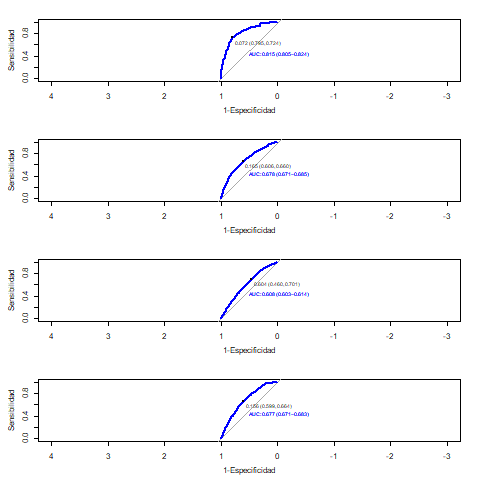

```python
%%R

modelos <- list(mod_elegido_a.b, mod_elegido_c.d, mod_elegido_e, mod_elegido_f.g)
dependientes <- list(XY_r$a.b, XY_r$c.d, XY_r$e, XY_r$f.g)

# Ajustar el tamaño de la ventana gráfica
options(repr.plot.width=30, repr.plot.height=60)
# Dividir el área de la gráfica en 7 filas y 2 columnas
par(mfrow=c(4, 1))

for (i in seq_along(modelos)) {

    cat('----------------------------------------------------------------- \n')
    cat('Variable objetivo: ', all.vars(formula(modelos[[i]]))[1], '\n')
    cat('----------------------------------------------------------------- \n')

    # Obtener variables
    dependiente <- dependientes[[i]]
    mod_elegido <- modelos[[i]]

    # Los datos que se pasan para predecir son los mismos del fichero
    XY_r$probb <- predict(mod_elegido, XY_r, type= 'response')
    objroc <- roc(dependiente, XY_r$probb ,auc=T,ci=T)

    plot.roc(objroc, print.auc=T, print.thres = 'best',
             col='blue',xlab='1-Especificidad',ylab='Sensibilidad')

    SensEspec <-objroc$sensitivities + objroc$specificities
    maximo    <- max(SensEspec)
    numOrdenCutoff <- which(SensEspec == maximo)
    print(objroc$thresholds[numOrdenCutoff])

    ##########

    # Hacemos el resumen gráfico del resultado
    # hist(100*XY_r$probb, col='skyblue',
    #     main='Resultados modelo glm() sobre datos Certificados energéticos',
    #     xlab='Probabilidad en % de supervivencia',
    #     ylab='Frecuencia')
    # Marcamos un umbral en el que consideramos el pronostico como donación
    # este umbral lo ponemos en un valor del 60%
    # abline(v= 100*objroc$thresholds[numOrdenCutoff],col= 'navy', lwd=3)  # marcamos el umbral de supervivencia

    ################################################################################
    # RESULTADOS

    XY_r$predicc <- ifelse(XY_r$probb > objroc$thresholds[numOrdenCutoff],1,0)
    table(dependiente,XY_r$predicc)

    positivos <- sum(dependiente == 1)
    negativos <- sum(dependiente == 0)
    predichos_positivos <- sum(XY_r$predicc == 1)
    predichos_negativos <- sum(XY_r$predicc == 0)

    total <- nrow(XY_r)

    print(data.frame(positivos, negativos,predichos_positivos,predichos_negativos))

    # Calcular la matriz de confusión
    confusion_matrix <- table(dependiente, XY_r$predicc)

    tp <- confusion_matrix[2, 2]
    tn <- confusion_matrix[1, 1]
    fp <- confusion_matrix[1, 2]
    fn <- confusion_matrix[2, 1]
    print(data.frame(tp, tn,fp,fn))

    A.accuracy <- (tp+tn)/total
    B.error_rate <- (fp+fn)/total
    C.sensitivity <- tp/positivos
    D.especificity <- tn/negativos
    E.precision <- tp/predichos_positivos
    F.npv <- tn / predichos_negativos
    cat('Accuracy: ', A.accuracy, '\n')
    cat('Error Rate: ', B.error_rate, '\n')
    cat('Sensitivity: ', C.sensitivity, '\n')
    cat('Specificity: ', D.especificity, '\n')
    cat('Precision: ', E.precision, '\n')
    cat('Negative Predictive Value (NPV): ', F.npv, '\n')
}
```

## Regresión logística phyton

fisher_var_ind = {'A-B': ['0 < año <= 1981', '1 < m2 <= 56', '110 < m2 <= 1245', '1981 < año <= 2005', '2005 < año <= 2022', '56 < m2 <= 72', '72 < m2 <= 90', '90 < m2 <= 110', 'Almacén - Estacionamiento', 'Reforma media', 'Reforma total', 'Rehabilitación integral', 'Residencial', 'Sin reformar', 'ZC-C3', 'ZC-C4', 'ZC-D3'], 'C-D': ['0 < año <= 1981', '1981 < año <= 2005', '2005 < año <= 2022', '56 < m2 <= 72', '72 < m2 <= 90', '90 < m2 <= 110', 'Comercial', 'Cultural', 'Deportivo', 'Obras de urbanización y jardinería, suelos sin edificar', 'Reforma media', 'Reforma mínima', 'Reforma total', 'Rehabilitación integral', 'Residencial', 'Sin reformar', 'ZC-C3'], 'E': ['0 < año <= 1981', '1 < m2 <= 56', '1981 < año <= 2005', '2005 < año <= 2022', '56 < m2 <= 72', '72 < m2 <= 90', '90 < m2 <= 110', 'Almacén - Estacionamiento', 'Badajoz', 'Cultural', 'Cáceres', 'Obras de urbanización y jardinería, suelos sin edificar', 'Reforma total', 'Rehabilitación integral', 'Residencial', 'ZC-C3', 'ZC-C4', 'ZC-D3'], 'F-G': ['0 < año <= 1981', '1 < m2 <= 56', '110 < m2 <= 1245', '1981 < año <= 2005', '2005 < año <= 2022', '56 < m2 <= 72', '72 < m2 <= 90', 'Badajoz', 'Cáceres', 'Reforma media', 'Reforma mínima', 'Reforma total', 'Rehabilitación integral', 'Sin reformar', 'ZC-C4', 'ZC-D3']}

```python
fisher_var_ind = {'A-B': ['1 < m2 <= 56', '110 < m2 <= 1245', '1981 < año <= 2005', '2005 < año <= 2022', '56 < m2 <= 72', 'Reforma media', 'Reforma total', 'Residencial', 'Sin reformar', 'ZC-C3', 'longitud', 'renta_neta_por_hogar'],
                  'C-D': ['2005 < año <= 2022', '56 < m2 <= 72', '72 < m2 <= 90', '90 < m2 <= 110', 'Comercial', 'Cultural', 'Deportivo', 'Obras de urbanización y jardinería, suelos sin edificar', 'Reforma total', 'Residencial', 'Sin reformar', 'ZC-C3', 'altitud', 'renta_neta_por_hogar'],
                  'E': ['0 < año <= 1981', '1981 < año <= 2005','72 < m2 <= 90', '90 < m2 <= 110', 'Cultural', 'Reforma total', 'Residencial', 'altitud', 'longitud', 'renta_neta_por_hogar'],
                  'F-G': ['0 < año <= 1981', '1 < m2 <= 56', '110 < m2 <= 1245', 'Badajoz', 'Sin reformar', 'ZC-C4', 'ZC-D3', 'latitud', 'altitud', 'longitud', 'renta_neta_por_hogar']}
```

```
Columna objetivo: A-B
```

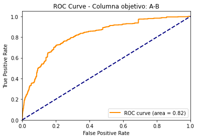

```
   test/pred    1      0
0          1    2      0
1          0  565  10098
Variables seleccionadas: Index(['1 < m2 <= 56', '110 < m2 <= 1245', '1981 < año <= 2005',
       '2005 < año <= 2022', '56 < m2 <= 72', 'Reforma media', 'Reforma total',
       'Residencial', 'Sin reformar', 'ZC-C3', 'longitud',
       'renta_neta_por_hogar'],
      dtype='object')
- Accuracy: 0.947022972339428
- Error Rate: 0.052977027660571996
- Sensitivity (Recall): 0.003527336860670194
- Specificity: 1.0
- Precision: 1.0
- Negative Predictive Value (NPV): 0.9470130357310326
----------------------------------------
Columna objetivo: C-D
```

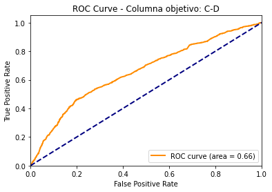

```
   test/pred     1     0
0          1     4     3
1          0  1828  8830
Variables seleccionadas: Index(['2005 < año <= 2022', '56 < m2 <= 72', '72 < m2 <= 90',
       '90 < m2 <= 110', 'Comercial', 'Cultural', 'Deportivo',
       'Obras de urbanización y jardinería, suelos sin edificar',
       'Reforma total', 'Residencial', 'Sin reformar', 'ZC-C3', 'altitud',
       'renta_neta_por_hogar'],
      dtype='object')
- Accuracy: 0.8283169245194562
- Error Rate: 0.17168307548054385
- Sensitivity (Recall): 0.002183406113537118
- Specificity: 0.9996603645420582
- Precision: 0.5714285714285714
- Negative Predictive Value (NPV): 0.8284856445862263
----------------------------------------
Columna objetivo: E
```

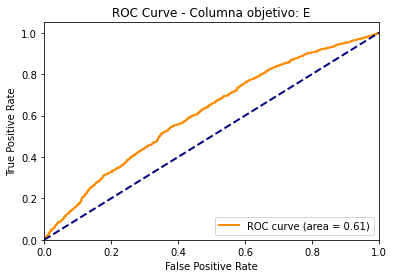

```
   test/pred     1     0
0          1  5553  3036
1          0   936  1140
Variables seleccionadas: Index(['0 < año <= 1981', '1981 < año <= 2005', '72 < m2 <= 90',
       '90 < m2 <= 110', 'Cultural', 'Reforma total', 'Residencial', 'altitud',
       'longitud', 'renta_neta_por_hogar'],
      dtype='object')
- Accuracy: 0.6275668073136428
- Error Rate: 0.3724331926863572
- Sensitivity (Recall): 0.855755894590846
- Specificity: 0.27298850574712646
- Precision: 0.6465246245197346
- Negative Predictive Value (NPV): 0.5491329479768786
----------------------------------------
Columna objetivo: F-G
```

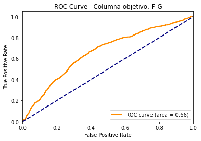

```
   test/pred     1     0
0          1     0     0
1          0  1777  8888
Variables seleccionadas: Index(['0 < año <= 1981', '1 < m2 <= 56', '110 < m2 <= 1245', 'Badajoz',
       'Sin reformar', 'ZC-C4', 'ZC-D3', 'latitud', 'altitud', 'longitud',
       'renta_neta_por_hogar'],
      dtype='object')
- Accuracy: 0.8333802156586967
- Error Rate: 0.1666197843413033
- Sensitivity (Recall): 0.0
- Specificity: 1.0
- Precision: 0.0
- Negative Predictive Value (NPV): 0.8333802156586967
----------------------------------------
```

```python
for columna_objetivo in Y.columns:

    # Obtain the input data (X) and the target column (y) for the current target column
    X_current = X[fisher_var_ind[columna_objetivo]]
    y_current = Y[columna_objetivo]

    # Split the data into training and testing sets
    X_train, X_test, y_train, y_test = train_test_split(X_current, y_current, test_size=0.25, random_state=42)

    # Se ajusta un modelo KNN
    # Ajuste de una regresión logística a train
    clf = LogisticRegression()
    clf.fit(X_train, y_train)

    # Predict on test set
    y_pred = clf.predict(X_test)
    # Predict on test set probability (ROC)
    y_pred_prob = clf.predict_proba(X_test)[:, 1]

    # Calculate the ROC curve
    fpr, tpr, thresholds = roc_curve(y_test, y_pred_prob)

    # Calculate the Area Under the ROC Curve (AUC)
    roc_auc = auc(fpr, tpr)

    # Plot the ROC curve
    print(f'Columna objetivo: {columna_objetivo}')
    plt.figure()
    plt.plot(fpr, tpr, color='darkorange', lw=2, label=f'ROC curve (area = {roc_auc:.2f})')
    plt.plot([0, 1], [0, 1], color='navy', lw=2, linestyle='--')
    plt.xlim([0.0, 1.0])
    plt.ylim([0.0, 1.05])
    plt.xlabel('False Positive Rate')
    plt.ylabel('True Positive Rate')
    plt.title(f'ROC Curve - Columna objetivo: {columna_objetivo}')
    plt.legend(loc='lower right')
    plt.show()

    # Calculate the confusion matrix
    cm = confusion_matrix(y_test, y_pred)

    # Extract metrics from the confusion matrix
    tn, fp, fn, tp = cm.ravel()
    metrics = pd.DataFrame({'test/pred':(1,0),1:(tp, fn),0:(fp, tn)})
    print(metrics)

    accuracy = accuracy_score(y_test, y_pred)
    error_rate = 1 - accuracy
    sensitivity = recall_score(y_test, y_pred)
    specificity = tn / (tn + fp)
    precision = precision_score(y_test, y_pred)
    npv = tn / (tn + fn)

    # Print the metrics for the current target column

    print(f'Variables seleccionadas: {X_current.columns}')
    print(f'- Accuracy: {accuracy}')
    print(f'- Error Rate: {error_rate}')
    print(f'- Sensitivity (Recall): {sensitivity}')
    print(f'- Specificity: {specificity}')
    print(f'- Precision: {precision}')
    print(f'- Negative Predictive Value (NPV): {npv}')
    print('-' * 40)
```

## Árbol de decisión

```
Columna objetivo: A-B
```

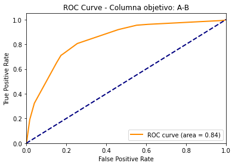

```
   test/pred    1      0
0          1    2      5
1          0  565  10093
Variables seleccionadas: Index(['1 < m2 <= 56', '110 < m2 <= 1245', '1981 < año <= 2005',
       '2005 < año <= 2022', '56 < m2 <= 72', 'Reforma media', 'Reforma total',
       'Residencial', 'Sin reformar', 'ZC-C3', 'longitud',
       'renta_neta_por_hogar'],
      dtype='object')
- Accuracy: 0.9465541490857946
- Error Rate: 0.053445850914205395
- Sensitivity (Recall): 0.003527336860670194
- Specificity: 0.9995048524460289
- Precision: 0.2857142857142857
- Negative Predictive Value (NPV): 0.9469881778945393
```

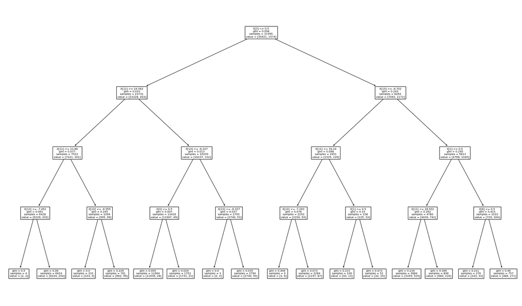

```
----------------------------------------
Columna objetivo: C-D
```

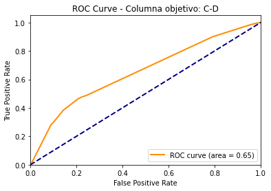

```
   test/pred     1     0
0          1     8    13
1          0  1824  8820
Variables seleccionadas: Index(['2005 < año <= 2022', '56 < m2 <= 72', '72 < m2 <= 90',
       '90 < m2 <= 110', 'Comercial', 'Cultural', 'Deportivo',
       'Obras de urbanización y jardinería, suelos sin edificar',
       'Reforma total', 'Residencial', 'Sin reformar', 'ZC-C3', 'altitud',
       'renta_neta_por_hogar'],
      dtype='object')
- Accuracy: 0.8277543366150961
- Error Rate: 0.17224566338490388
- Sensitivity (Recall): 0.004366812227074236
- Specificity: 0.9985282463489188
- Precision: 0.38095238095238093
- Negative Predictive Value (NPV): 0.8286358511837655
```

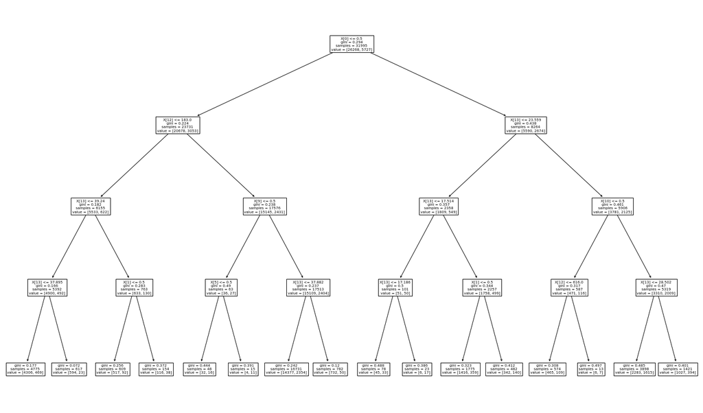

```
----------------------------------------
Columna objetivo: E
```

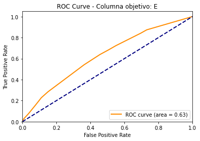

```
   test/pred     1     0
0          1  5671  3054
1          0   818  1122
Variables seleccionadas: Index(['0 < año <= 1981', '1981 < año <= 2005', '72 < m2 <= 90',
       '90 < m2 <= 110', 'Cultural', 'Reforma total', 'Residencial', 'altitud',
       'longitud', 'renta_neta_por_hogar'],
      dtype='object')
- Accuracy: 0.6369432723863103
- Error Rate: 0.3630567276136897
- Sensitivity (Recall): 0.8739405147172138
- Specificity: 0.2686781609195402
- Precision: 0.6499713467048711
- Negative Predictive Value (NPV): 0.5783505154639176
```

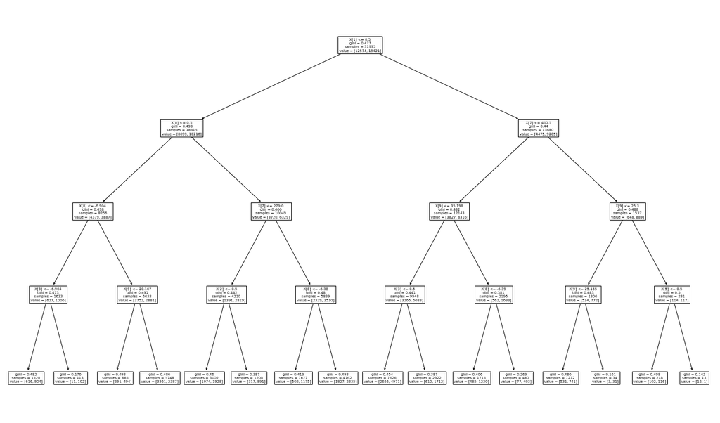

```
----------------------------------------
Columna objetivo: F-G
```

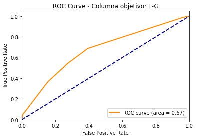

```
   test/pred     1     0
0          1    96    55
1          0  1681  8833
Variables seleccionadas: Index(['0 < año <= 1981', '1 < m2 <= 56', '110 < m2 <= 1245', 'Badajoz',
       'Sin reformar', 'ZC-C4', 'ZC-D3', 'latitud', 'altitud', 'longitud',
       'renta_neta_por_hogar'],
      dtype='object')
- Accuracy: 0.8372245663384904
- Error Rate: 0.1627754336615096
- Sensitivity (Recall): 0.05402363534046145
- Specificity: 0.9938118811881188
- Precision: 0.6357615894039735
- Negative Predictive Value (NPV): 0.8401179379874453
```

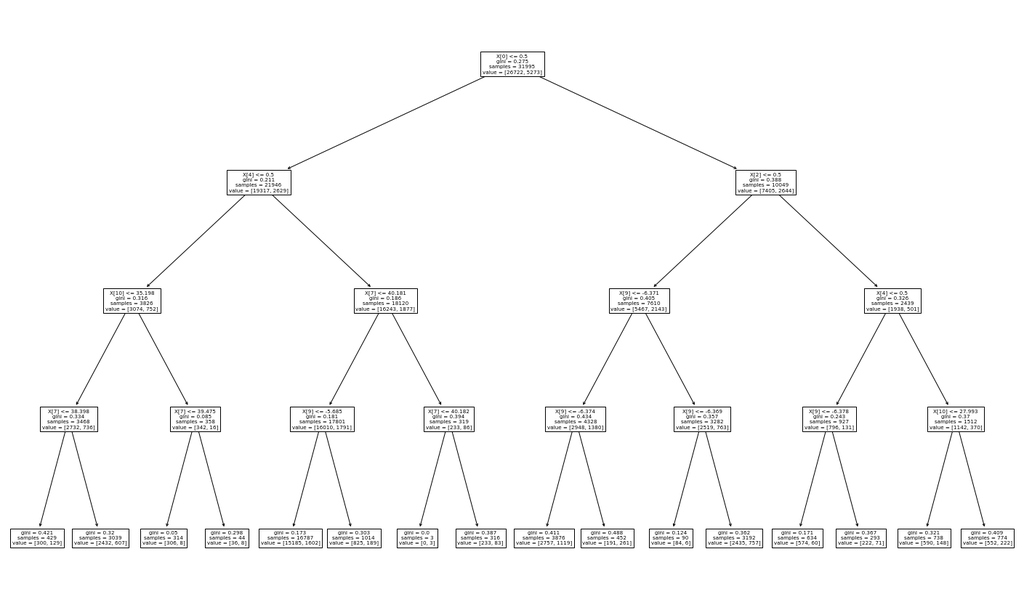

```python
for columna_objetivo in Y.columns:

    # Obtain the input data (X) and the target column (y) for the current target column
    X_current = X[fisher_var_ind[columna_objetivo]]
    y_current = Y[columna_objetivo]

    # Split the data into training and testing sets
    X_train, X_test, y_train, y_test = train_test_split(X_current, y_current, test_size=0.25, random_state=42)

    # Se ajusta un árbol de decisión
    depth = 4
    clf = DecisionTreeClassifier(max_depth=depth)
    clf.fit(X_train, y_train)

    # Predict on test set
    y_pred = clf.predict(X_test)
    # Predict on test set probability (ROC)
    y_pred_prob = clf.predict_proba(X_test)[:, 1]

    # Calculate the ROC curve
    fpr, tpr, thresholds = roc_curve(y_test, y_pred_prob)

    # Calculate the Area Under the ROC Curve (AUC)
    roc_auc = auc(fpr, tpr)

    # Plot the ROC curve
    print(f'Columna objetivo: {columna_objetivo}')
    plt.figure()
    plt.plot(fpr, tpr, color='darkorange', lw=2, label=f'ROC curve (area = {roc_auc:.2f})')
    plt.plot([0, 1], [0, 1], color='navy', lw=2, linestyle='--')
    plt.xlim([0.0, 1.0])
    plt.ylim([0.0, 1.05])
    plt.xlabel('False Positive Rate')
    plt.ylabel('True Positive Rate')
    plt.title(f'ROC Curve - Columna objetivo: {columna_objetivo}')
    plt.legend(loc='lower right')
    plt.show()

    # Calculate the confusion matrix
    cm = confusion_matrix(y_test, y_pred)

    # Extract metrics from the confusion matrix
    tn, fp, fn, tp = cm.ravel()
    metrics = pd.DataFrame({'test/pred':(1,0),1:(tp, fn),0:(fp, tn)})
    print(metrics)

    accuracy = accuracy_score(y_test, y_pred)
    error_rate = 1 - accuracy
    sensitivity = recall_score(y_test, y_pred)
    specificity = tn / (tn + fp)
    precision = precision_score(y_test, y_pred)
    npv = tn / (tn + fn)

    # Print the metrics for the current target column

    print(f'Variables seleccionadas: {X_current.columns}')
    print(f'- Accuracy: {accuracy}')
    print(f'- Error Rate: {error_rate}')
    print(f'- Sensitivity (Recall): {sensitivity}')
    print(f'- Specificity: {specificity}')
    print(f'- Precision: {precision}')
    print(f'- Negative Predictive Value (NPV): {npv}')

    fig, ax = plt.subplots(figsize=(25, 15))
    _ = tree.plot_tree(clf, )
    plt.show()
    print('-' * 40)
```

## K-vecinos (KNN)

```
Columna objetivo: A-B
```

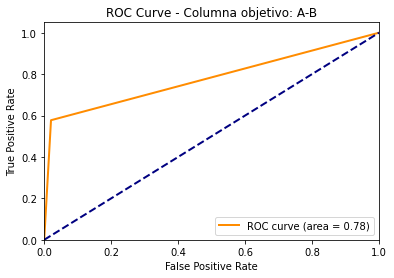

```
   test/pred    1     0
0          1  272   164
1          0  199  7897
Variables seleccionadas: Index(['1 < m2 <= 56', '110 < m2 <= 1245', '1981 < año <= 2005',
       '2005 < año <= 2022', '56 < m2 <= 72', 'Reforma media', 'Reforma total',
       'Residencial', 'Sin reformar', 'ZC-C3', 'longitud',
       'renta_neta_por_hogar'],
      dtype='object')
- Accuracy: 0.9574542897327707
- Error Rate: 0.04254571026722931
- Sensitivity (Recall): 0.5774946921443737
- Specificity: 0.9796551296365216
- Precision: 0.6238532110091743
- Negative Predictive Value (NPV): 0.9754199604743083
----------------------------------------
Columna objetivo: C-D
```

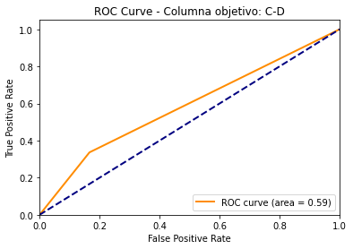

```
   test/pred    1     0
0          1  479  1181
1          0  945  5927
Variables seleccionadas: Index(['2005 < año <= 2022', '56 < m2 <= 72', '72 < m2 <= 90',
       '90 < m2 <= 110', 'Comercial', 'Cultural', 'Deportivo',
       'Obras de urbanización y jardinería, suelos sin edificar',
       'Reforma total', 'Residencial', 'Sin reformar', 'ZC-C3', 'altitud',
       'renta_neta_por_hogar'],
      dtype='object')
- Accuracy: 0.7508204406938584
- Error Rate: 0.24917955930614155
- Sensitivity (Recall): 0.336376404494382
- Specificity: 0.8338491840180079
- Precision: 0.2885542168674699
- Negative Predictive Value (NPV): 0.8624854481955763
----------------------------------------
Columna objetivo: E
```

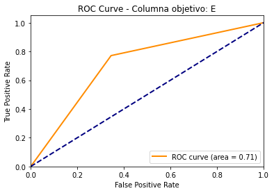

```
   test/pred     1     0
0          1  4007  1152
1          0  1188  2185
Variables seleccionadas: Index(['0 < año <= 1981', '1981 < año <= 2005', '72 < m2 <= 90',
       '90 < m2 <= 110', 'Cultural', 'Reforma total', 'Residencial', 'altitud',
       'longitud', 'renta_neta_por_hogar'],
      dtype='object')
- Accuracy: 0.7257383966244726
- Error Rate: 0.2742616033755274
- Sensitivity (Recall): 0.7713185755534168
- Specificity: 0.6547797422834881
- Precision: 0.7767009110292692
- Negative Predictive Value (NPV): 0.6477912837236881
----------------------------------------
Columna objetivo: F-G
```

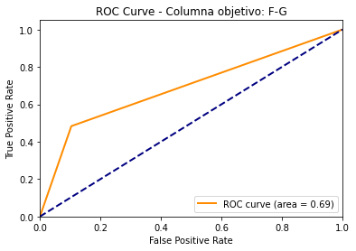

```
   test/pred    1     0
0          1  697   736
1          0  745  6354
Variables seleccionadas: Index(['0 < año <= 1981', '1 < m2 <= 56', '110 < m2 <= 1245', 'Badajoz',
       'Sin reformar', 'ZC-C4', 'ZC-D3', 'latitud', 'altitud', 'longitud',
       'renta_neta_por_hogar'],
      dtype='object')
- Accuracy: 0.826418190342241
- Error Rate: 0.17358180965775905
- Sensitivity (Recall): 0.48335644937586686
- Specificity: 0.8961918194640338
- Precision: 0.48639218422889047
- Negative Predictive Value (NPV): 0.8950556416396676
----------------------------------------
```

```python
for columna_objetivo in Y.columns:

    # Obtain the input data (X) and the target column (y) for the current target column
    X_current = X[fisher_var_ind[columna_objetivo]]
    y_current = Y[columna_objetivo]

    # Split the data into training and testing sets
    X_train, X_test, y_train, y_test = train_test_split(X_current, y_current, test_size=0.2, random_state=42)

    # Se ajusta un modelo KNN
    clf = KNeighborsClassifier(n_neighbors=1)
    clf.fit(X_train, y_train)

    # Predict on test set
    y_pred = clf.predict(X_test)
    # Predict on test set probability (ROC)
    y_pred_prob = clf.predict_proba(X_test)[:, 1]

    # Calculate the ROC curve
    fpr, tpr, thresholds = roc_curve(y_test, y_pred_prob)

    # Calculate the Area Under the ROC Curve (AUC)
    roc_auc = auc(fpr, tpr)

    # Plot the ROC curve
    print(f'Columna objetivo: {columna_objetivo}')
    plt.figure()
    plt.plot(fpr, tpr, color='darkorange', lw=2, label=f'ROC curve (area = {roc_auc:.2f})')
    plt.plot([0, 1], [0, 1], color='navy', lw=2, linestyle='--')
    plt.xlim([0.0, 1.0])
    plt.ylim([0.0, 1.05])
    plt.xlabel('False Positive Rate')
    plt.ylabel('True Positive Rate')
    plt.title(f'ROC Curve - Columna objetivo: {columna_objetivo}')
    plt.legend(loc='lower right')
    plt.show()

    # Calculate the confusion matrix
    cm = confusion_matrix(y_test, y_pred)

    # Extract metrics from the confusion matrix
    tn, fp, fn, tp = cm.ravel()
    metrics = pd.DataFrame({'test/pred':(1,0),1:(tp, fn),0:(fp, tn)})
    print(metrics)

    accuracy = accuracy_score(y_test, y_pred)
    error_rate = 1 - accuracy
    sensitivity = recall_score(y_test, y_pred)
    specificity = tn / (tn + fp)
    precision = precision_score(y_test, y_pred)
    npv = tn / (tn + fn)

    # Print the metrics for the current target column

    print(f'Variables seleccionadas: {X_current.columns}')
    print(f'- Accuracy: {accuracy}')
    print(f'- Error Rate: {error_rate}')
    print(f'- Sensitivity (Recall): {sensitivity}')
    print(f'- Specificity: {specificity}')
    print(f'- Precision: {precision}')
    print(f'- Negative Predictive Value (NPV): {npv}')
    print('-' * 40)
```

# Conclusiones

Aclarados estos 3 puntos principales se llega a la conclusión de que los datos del dataset no son adecuados predecir la calificación energética de las viviendas. Puntos analizados por los cuales los datos de calificación energética no son adecuados como varible objetivo: 1) Existen certificados energéticos que pertenecen a suelos clasificados en Catastro como "Suelos sin edificar", por lo que dicha información se pierde al desconocer el año de construcción, los m2, el tipo de rehabilitación... 2) Catastro tiene un gran número de viviendas clasificadas con años anteriores a 1981 con certificación A-B esto es debido a que la fecha de los registros es la de construccion en caso algún tipo de reforma en fachada la de la reforma. Por tanto, no se consideran las reformas de los pisos individualmente. 3) Hay algunos registros en Agile cuyo código de referencia catastral no es correcto:

```
- CL PILAR 44 -- Catastro: 5350263QC2855S0001OI (2016) -- AGILE: 5350258QC2855S0001F1 (1968 (A))
- SUELO SIN EDIFICAR -- Catastro: 7105437QD2770E0001OD -- AGILE: 7105426QD27770E0001YD (A)
```